# RNA-seq workflow: gene-level exploratory analysis and differential expression

Michael I. Love, Simon Anders, Vladislav Kim and Wolfgang Huber

Department of Biostatistics, UNC-Chapel Hill, Chapel Hill, NC, US  
Department of Genetics, UNC-Chapel Hill, Chapel Hill, NC, US  
Zentrum für Molekulare Biologie der Universität Heidelberg, Heidelberg, Germany  
European Molecular Biology Laboratory (EMBL), Heidelberg, Germany

16 October, 2019

#### Abstract

Here we walk through an end-to-end gene-level RNA-seq differential expression workflow using Bioconductor packages. We will start from the FASTQ files, show how these were quantified to the reference transcripts, and prepare gene-level count datasets for downstream analysis. We will perform exploratory data analysis (EDA) for quality assessment and to explore the relationship between samples, perform differential gene expression analysis, and visually explore the results.

# Contents

**R version**: R version 3.6.1 (2019-07-05)

**Bioconductor version**: 3.10

**Package**: 1.10.0

# 1 Introduction

Bioconductor has many packages which support analysis of high-throughput sequence data, including RNA sequencing (RNA-seq). The packages which we will use in this workflow include core packages maintained by the Bioconductor core team for working with gene annotations (gene and transcript locations in the genome, as well as gene ID lookup). We will also use contributed packages for statistical analysis and visualization of sequencing data. Through scheduled releases every 6 months, the Bioconductor project ensures that all the packages within a release will work together in harmony (hence the “conductor” metaphor). The packages used in this workflow are loaded with the *library* function and can be installed by following the [Bioconductor package installation instructions](http://bioconductor.org/install/#install-bioconductor-packages).

- A published version of this workflow, including reviewer reports and comments is available at [F1000Research](http://f1000research.com/articles/4-1070). The version you are reading now differs from this one, primarily in that we now give code for performing fast **transcript quantification** followed by import in R/Bioconductor to perform gene-level analysis.
- Another Bioconductor workflow covering **differential transcript usage** (DTU) is the rnaseqDTU workflow, with the published version likewise available at [F1000Research](https://f1000research.com/articles/7-952/v3).
- If you have questions about this workflow or any Bioconductor software, please post these to the [Bioconductor support site](https://support.bioconductor.org/). If the questions concern a specific package, you can tag the post with the name of the package, or for general questions about the workflow, tag the post with `rnaseqgene`. Note the [posting guide](http://www.bioconductor.org/help/support/posting-guide/) for crafting an optimal question for the support site.

## 1.1 Experimental data

The data used in this workflow is stored in the *airway* package that summarizes an RNA-seq experiment wherein airway smooth muscle cells were treated with dexamethasone, a synthetic glucocorticoid steroid with anti-inflammatory effects (Himes et al. 2014). Glucocorticoids are used, for example, by people with asthma to reduce inflammation of the airways. In the experiment, four primary human airway smooth muscle cell lines were treated with 1 micromolar dexamethasone for 18 hours. For each of the four cell lines, we have a treated and an untreated sample. For more description of the experiment see the [PubMed entry 24926665](http://www.ncbi.nlm.nih.gov/pubmed/24926665) and for raw data see the [GEO entry GSE52778](http://www.ncbi.nlm.nih.gov/geo/query/acc.cgi?acc=GSE52778).

# 2 Preparing quantification input to DESeq2

As input, the count-based statistical methods, such as *DESeq2* (Love, Huber, and Anders 2014), *edgeR* (Robinson, McCarthy, and Smyth 2009), *limma* with the voom method (Law et al. 2014), *DSS* (Wu, Wang, and Wu 2013), *EBSeq* (Leng et al. 2013) and *baySeq* (Hardcastle and Kelly 2010), expect input data as obtained, e.g., from RNA-seq or another high-throughput sequencing experiment, in the form of a matrix of un-normalized counts. The value in the *i*-th row and the *j*-th column of the matrix tells how many reads (or fragments, for paired-end RNA-seq) can be assigned to gene *i* in sample *j*. Analogously, for other types of assays, the rows of the matrix might correspond e.g., to binding regions (with ChIP-Seq), or peptide sequences (with quantitative mass spectrometry).

The values in the matrix should be counts or estimated counts of sequencing reads/fragments. This is important for *DESeq2*’s statistical model to hold, as only counts allow assessing the measurement precision correctly. It is important to *never* provide counts that were pre-normalized for sequencing depth/library size, as the statistical model is most powerful when applied to un-normalized counts, and is designed to account for library size differences internally.

## 2.1 Transcript quantification and *tximport* / *tximeta*

A previous version of this workflow (including the published version) demonstrated how to align reads to the genome and then count the number of reads that are consistent with gene models. We now recommend a faster, alternative pipeline to genome alignment and read counting. This workflow will demonstrate how to import transcript-level quantification data, aggregating to the gene-level with *tximport* or *tximeta*. Transcript quantification methods such as [Salmon](https://combine-lab.github.io/salmon/) (Patro et al. 2017), [kallisto](https://pachterlab.github.io/kallisto/) (Bray et al. 2016), or [RSEM](http://deweylab.github.io/RSEM/) (Li and Dewey 2011) perform mapping or alignment of reads to reference transcripts, outputting estimated counts per transcript as well as effective transcript lengths which summarize bias effects. After running one of these tools, the *tximport* (Soneson, Love, and Robinson 2015) or *tximeta* (Love et al. 2019) packages can be used to assemble estimated count and offset matrices for use with Bioconductor differential gene expression packages, as will be demonstrated below.

A tutorial on how to use the *Salmon* software for quantifying transcript abundance can be found [here](https://combine-lab.github.io/salmon/getting_started/). We recommend using the `--gcBias` [flag](http://salmon.readthedocs.io/en/latest/salmon.html#gcbias) which estimates a correction factor for systematic biases commonly present in RNA-seq data (Love, Hogenesch, and Irizarry 2016; Patro et al. 2017), unless you are certain that your data do not contain such bias.

The advantages of using the transcript abundance quantifiers in conjunction with *tximport*/*tximeta* to produce gene-level count matrices and normalizing offsets, are: (1) this approach corrects for any potential changes in gene length across samples (e.g. from differential isoform usage) (Trapnell et al. 2013); (2) some of these methods are substantially faster and require less memory and disk usage compared to alignment-based methods; and (3) it is possible to avoid discarding those fragments that can align to multiple genes with homologous sequence (Robert and Watson 2015). Note that transcript abundance quantifiers skip the generation of large files which store read alignments, instead producing smaller files which store estimated abundances, counts, and effective lengths per transcript. For more details, see the manuscript describing this approach (Soneson, Love, and Robinson 2015), and the *tximport* package vignette for software details.

*tximeta* (Love et al. 2019) extends *tximport*, offering the same functionality, plus the additional benefit of automatic addition of annotation metadata for commonly used transcriptomes (GENCODE, Ensembl, RefSeq for human and mouse). See the [tximeta vignette](https://bioconductor.org/packages/release/bioc/vignettes/tximeta/inst/doc/tximeta.htmlm) package vignette for more details. *tximeta* produces a *SummarizedExperiment* that can be loaded easily into *DESeq2* using the `DESeqDataSet` function, which will be demonstrated below. We will also discuss the various possible inputs into *DESeq2*, whether using *tximport*, *tximeta*, *htseq* (Anders, Pyl, and Huber 2015), or a pre-computed count matrix.

## 2.2 Quantifying with *Salmon*

As mentioned above, a short tutorial on how to use *Salmon* can be found [here](https://combine-lab.github.io/salmon/getting_started/), so instead we will provide the code that was used to quantify the files used in this workflow. *Salmon* can be conveniently run on a cluster using the [Snakemake](https://snakemake.readthedocs.io/en/stable/) workflow management system (Köster and Rahmann 2012).

The following `Snakemake` file was used to quantify the eight samples that were downloaded from the SRA (the SRR identifier is the run identifier, and there was only one run per sample for these eight samples).

```
DATASETS = ["SRR1039508",
            "SRR1039509",
            "SRR1039512",
            "SRR1039513",
            "SRR1039516",
            "SRR1039517",
            "SRR1039520",
            "SRR1039521"]

SALMON = "/path/to/salmon_0.14.1/bin/salmon"

rule all:
  input: expand("quants/{dataset}/quant.sf", dataset=DATASETS)

rule salmon_quant:
    input:
        r1 = "fastq/{sample}_1.fastq.gz",
        r2 = "fastq/{sample}_2.fastq.gz",
        index = "/path/to/gencode.v29_salmon_0.14.1"
    output:
        "quants/{sample}/quant.sf"
    params:
        dir = "quants/{sample}"
    shell:
        "{SALMON} quant -i {input.index} -l A -p 6 --validateMappings \
         --gcBias --numGibbsSamples 20 -o {params.dir} \
         -1 {input.r1} -2 {input.r2}"
```

The last line is the key one which runs *Salmon*. It says to quantify using a specific *index*, with automatic library type detection, using 6 threads, with the validate mappings setting (this is default in versions of *Salmon* $\ge$ 0.99), with GC bias correction, and writing out 20 Gibbs samples (this is optional). The last three arguments specify the output directory and the two paired read files.

The above Snakemake file requires that an index be created at `/path/to/gencode.vVV_salmon_X.Y.Z`, where VV and X,Y,Z should help specify the release of the reference transcripts and of *Salmon*. For human and mouse reference transcripts, we recommend to use [GENCODE](https://gencodegenes.org) (Frankish et al. 2018).

The *Salmon* index can be created easily with the following command:

```
salmon index -t transcripts.fa.gz -i name_of_index
```

If the transcripts are downloaded from GENCODE, it is recommended to use something similar to the following command (which simply helps to strip the extra information from the transcript names):

```
salmon index --gencode -t gencode.v29.transcripts.fa.gz \
  -i gencode.v29_salmon_X.Y.Z
```

The above Snakemake file can then be used to [execute Snakemake](https://snakemake.readthedocs.io/en/stable/executable.html) in various ways, including submitting multiple jobs to a compute cluster or in the cloud. The above Snakemake file was executed on a cluster with SLURM scheduling, with the following line in a separate job submitted to the cluster:

```
snakemake -j 4 --latency-wait 30 --cluster "sbatch -N 1 -n 6"
```

## 2.3 Reading in data with *tximeta*

Later in the workflow, we will load an object that contains the quantification data at the gene-level for all eight samples. However, the *airway* package also contains two quantification directories output by *Salmon*, in order to demonstrate reading this data into R/Bioconductor. In order to make the data package smaller, the `quant.sf` files in the quantification directories have been gzipped, so below where you see `quant.sf.gz`, you would probably use `quant.sf` on your own machine.

After we demonstrate importing with *tximeta*, we will load the full count matrix corresponding to all samples and all data, which is already provided in the same package, and will continue the analysis with that full data object.

We first load the data package with the example data:

```r
library("airway")
```

The R function *system.file* can be used to find out where on your computer the files from a package have been installed. Here we ask for the full path to the `extdata` directory, where R packages store external data, that is part of the *airway* package.

```r
dir <- system.file("extdata", package="airway", mustWork=TRUE)
```

In this directory, we find a number of files, including eight BAM files that were used in the previous version of this workflow demonstrating alignment and counting. We will focus on the two directories that are in the `quants` directory, which contain the output from *Salmon* on two files.

```r
list.files(dir)
```

```
##  [1] "GSE52778_series_matrix.txt"        "Homo_sapiens.GRCh37.75_subset.gtf"
##  [3] "SRR1039508_subset.bam"             "SRR1039509_subset.bam"
##  [5] "SRR1039512_subset.bam"             "SRR1039513_subset.bam"
##  [7] "SRR1039516_subset.bam"             "SRR1039517_subset.bam"
##  [9] "SRR1039520_subset.bam"             "SRR1039521_subset.bam"
## [11] "SraRunInfo_SRP033351.csv"          "quants"
## [13] "sample_table.csv"
```

```r
list.files(file.path(dir, "quants"))
```

```
## [1] "SRR1039508" "SRR1039509"
```

Typically, we have a table with detailed information for each of our samples that links samples to the associated FASTQ and *Salmon* directories. For your own project, you might create such a comma-separated value (CSV) file using a text editor or spreadsheet software such as Excel.

We load such a CSV file with *read.csv*:

```r
csvfile <- file.path(dir, "sample_table.csv")
coldata <- read.csv(csvfile, row.names=1, stringsAsFactors=FALSE)
coldata
```

```
##            SampleName    cell   dex albut        Run avgLength Experiment
## SRR1039508 GSM1275862  N61311 untrt untrt SRR1039508       126  SRX384345
## SRR1039509 GSM1275863  N61311   trt untrt SRR1039509       126  SRX384346
## SRR1039512 GSM1275866 N052611 untrt untrt SRR1039512       126  SRX384349
## SRR1039513 GSM1275867 N052611   trt untrt SRR1039513        87  SRX384350
## SRR1039516 GSM1275870 N080611 untrt untrt SRR1039516       120  SRX384353
## SRR1039517 GSM1275871 N080611   trt untrt SRR1039517       126  SRX384354
## SRR1039520 GSM1275874 N061011 untrt untrt SRR1039520       101  SRX384357
## SRR1039521 GSM1275875 N061011   trt untrt SRR1039521        98  SRX384358
##               Sample    BioSample
## SRR1039508 SRS508568 SAMN02422669
## SRR1039509 SRS508567 SAMN02422675
## SRR1039512 SRS508571 SAMN02422678
## SRR1039513 SRS508572 SAMN02422670
## SRR1039516 SRS508575 SAMN02422682
## SRR1039517 SRS508576 SAMN02422673
## SRR1039520 SRS508579 SAMN02422683
## SRR1039521 SRS508580 SAMN02422677
```

To demonstrate loading *Salmon* quantifiation data into R, we will just work with the two samples that are provided in the *airway* package. We create a column called `names` and a column called `files`:

```r
coldata <- coldata[1:2,]
coldata$names <- coldata$Run
coldata$files <- file.path(dir, "quants", coldata$names, "quant.sf.gz")
file.exists(coldata$files)
```

```
## [1] TRUE TRUE
```

Now we load the *tximeta* package and run its main function:

```r
library("tximeta")
se <- tximeta(coldata)
```

```
## importing quantifications
```

```
## reading in files with read_tsv
```

```
## 1 2
## found matching transcriptome:
## [ GENCODE - Homo sapiens - release 29 ]
## building TxDb with 'GenomicFeatures' package
## Import genomic features from the file as a GRanges object ... OK
## Prepare the 'metadata' data frame ... OK
## Make the TxDb object ... OK
## generating transcript ranges
## fetching genome info for GENCODE
```

If the reference transcriptome checksum was recognized by tximeta (details on this in the *tximeta* vignette), and if we have a working internet connection, *tximeta* will locate and download the relevant annotation data from various sources. A few details: the annotation data is only downloaded and parsed once, subsequently it will used locally cached versions of the metadata as needed (if you load data a second time that was quantified against the same reference transcripts). Also, the very first time that one uses *tximeta*, it will ask you to approve the default cache location (following the paradigm of the cache location used by other R and Bioconductor packages). You can change this location at any point later.

We will discuss what is the structure of the `se` object in the next section, but we can first just consider the dimensions. Note that *tximeta* imports data at the *transcript level*.

```r
dim(se)
```

```
## [1] 205870      2
```

```r
head(rownames(se))
```

```
## [1] "ENST00000456328.2" "ENST00000450305.2" "ENST00000488147.1"
## [4] "ENST00000619216.1" "ENST00000473358.1" "ENST00000469289.1"
```

As this workflow is concerned with gene-level analysis, we will now summarize the transcript-level quantifications to the gene level (which internally makes use of the methods in *tximport* (Soneson, Love, and Robinson 2015)). The correct transcript-to-gene mapping table is automatically created based on the metadata stored within the `se` object.

```r
gse <- summarizeToGene(se)
```

```
## loading existing TxDb created: 2019-10-30 16:06:10
```

```
## obtaining transcript-to-gene mapping from TxDb
```

```
## generating gene ranges
```

```
## summarizing abundance
```

```
## summarizing counts
```

```
## summarizing length
```

Now we can check that the dimensions are reduced and the row IDs are now gene IDs:

```r
dim(gse)
```

```
## [1] 58294     2
```

```r
head(rownames(gse))
```

```
## [1] "ENSG00000000003.14" "ENSG00000000005.5"  "ENSG00000000419.12"
## [4] "ENSG00000000457.13" "ENSG00000000460.16" "ENSG00000000938.12"
```

## 2.4 *DESeq2* import functions

While the above section described use of *Salmon* and *tximeta*, there are many possible inputs to *DESeq2*, each of which have their own dedicated import functions. The following tools can be used generate or compile count data for use with *DESeq2*: *tximport* (Soneson, Love, and Robinson 2015), *tximeta* (Love et al. 2019), *htseq-count* (Anders, Pyl, and Huber 2015), *featureCounts* (Liao, Smyth, and Shi 2014), *summarizeOverlaps* (Lawrence et al. 2013).

| function | package | framework | output | *DESeq2* input function |
| --- | --- | --- | --- | --- |
| *tximport* | *tximport* | R/Bioconductor | list of matrices | *DESeqDataSetFromTximport* |
| *tximeta* | *tximeta* | R/Bioconductor | *SummarizedExperiment* | *DESeqDataSet* |
| *htseq-count* | HTSeq | Python | files | *DESeqDataSetFromHTSeq* |
| *featureCounts* | *Rsubread* | R/Bioconductor | matrix | *DESeqDataSetFromMatrix* |
| *summarizeOverlaps* | *GenomicAlignments* | R/Bioconductor | *SummarizedExperiment* | *DESeqDataSet* |

We will next describe the class of object created by *tximeta* which was saved above as `se` and `gse`, and how to create a *DESeqDataSet* object from this for use with *DESeq2* (the other functions above also create a *DESeqDataSet*).

## 2.5 SummarizedExperiment

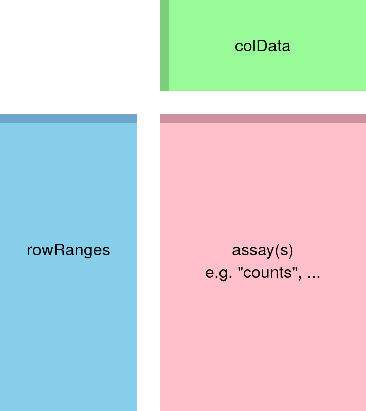

**The component parts of a *SummarizedExperiment* object.** The `assay` (pink block) contains the matrix of counts, the `rowRanges` (blue block) contains information about the genomic ranges and the `colData` (green block) contains information about the samples. The highlighted line in each block represents the first row (note that the first row of `colData` lines up with the first column of the `assay`).

The *SummarizedExperiment* container is diagrammed in the Figure above and discussed in the latest Bioconductor paper (Huber et al. 2015). In our case, *tximeta* has created an object `gse` with three matrices: “counts” - the estimated fragment counts for each gene and sample, “abundance” - the estimated transcript abundances in TPM, and “length” - the effective gene lengths which include changes in length due to biases as well as due to transcript usage. The names of the assays can be examined with *assayNames*, and the assays themselves are stored as `assays` (a list of matrices). The first matrix in the list can be pulled out via `assay`. The `rowRanges` for our object is the *GRanges* of the genes (from the left-most position of all the transcripts to the right-most position of all the transcripts). The component parts of the *SummarizedExperiment* are accessed with an R function of the same name: `assay` (or `assays`), `rowRanges` and `colData`.

We now will load the full count matrix corresponding to all samples and all data, which is provided in the *airway* package, and will continue the analysis with the full data object. We can investigate this *SummarizedExperiment* object by looking at the matrices in the `assays` slot, the phenotypic data about the samples in `colData` slot, and the data about the genes in the `rowRanges` slot.

```r
data(gse)
gse
```

```
## class: RangedSummarizedExperiment
## dim: 58294 8
## metadata(6): tximetaInfo quantInfo ... txomeInfo txdbInfo
## assays(3): counts abundance length
## rownames(58294): ENSG00000000003.14 ENSG00000000005.5 ...
##   ENSG00000285993.1 ENSG00000285994.1
## rowData names(1): gene_id
## colnames(8): SRR1039508 SRR1039509 ... SRR1039520 SRR1039521
## colData names(3): names donor condition
```

The counts are the first matrix, so we can examine them with just `assay`:

```r
assayNames(gse)
```

```
## [1] "counts"    "abundance" "length"
```

```r
head(assay(gse), 3)
```

```
##                    SRR1039508 SRR1039509 SRR1039512 SRR1039513 SRR1039516
## ENSG00000000003.14    708.164    467.962    900.992    424.368   1188.295
## ENSG00000000005.5       0.000      0.000      0.000      0.000      0.000
## ENSG00000000419.12    455.000    510.000    604.000    352.000    583.000
##                    SRR1039517 SRR1039520 SRR1039521
## ENSG00000000003.14   1090.668    805.929    599.337
## ENSG00000000005.5       0.000      0.000      0.000
## ENSG00000000419.12    773.999    409.999    499.000
```

```r
colSums(assay(gse))
```

```
## SRR1039508 SRR1039509 SRR1039512 SRR1039513 SRR1039516 SRR1039517 SRR1039520
##   21100805   19298584   26145537   15688246   25268618   31891456   19683767
## SRR1039521
##   21813903
```

The `rowRanges`, when printed, shows the ranges for the first five and last five genes:

```r
rowRanges(gse)
```

```
## GRanges object with 58294 ranges and 1 metadata column:
##                      seqnames              ranges strand |
##                         <Rle>           <IRanges>  <Rle> |
##   ENSG00000000003.14     chrX 100627109-100639991      - |
##    ENSG00000000005.5     chrX 100584802-100599885      + |
##   ENSG00000000419.12    chr20   50934867-50958555      - |
##   ENSG00000000457.13     chr1 169849631-169894267      - |
##   ENSG00000000460.16     chr1 169662007-169854080      + |
##                  ...      ...                 ...    ... .
##    ENSG00000285990.1    chr14   19244904-19269380      - |
##    ENSG00000285991.1     chr6 149817937-149896011      - |
##    ENSG00000285992.1     chr8   47129262-47132628      + |
##    ENSG00000285993.1    chr18   46409197-46410645      - |
##    ENSG00000285994.1    chr10   12563151-12567351      + |
##                                 gene_id
##                             <character>
##   ENSG00000000003.14 ENSG00000000003.14
##    ENSG00000000005.5  ENSG00000000005.5
##   ENSG00000000419.12 ENSG00000000419.12
##   ENSG00000000457.13 ENSG00000000457.13
##   ENSG00000000460.16 ENSG00000000460.16
##                  ...                ...
##    ENSG00000285990.1  ENSG00000285990.1
##    ENSG00000285991.1  ENSG00000285991.1
##    ENSG00000285992.1  ENSG00000285992.1
##    ENSG00000285993.1  ENSG00000285993.1
##    ENSG00000285994.1  ENSG00000285994.1
##   -------
##   seqinfo: 25 sequences (1 circular) from hg38 genome
```

The `rowRanges` also contains metadata about the sequences (chromosomes in our case) in the `seqinfo` slot:

```r
seqinfo(rowRanges(gse))
```

```
## Seqinfo object with 25 sequences (1 circular) from hg38 genome:
##   seqnames seqlengths isCircular genome
##   chr1      248956422      FALSE   hg38
##   chr2      242193529      FALSE   hg38
##   chr3      198295559      FALSE   hg38
##   chr4      190214555      FALSE   hg38
##   chr5      181538259      FALSE   hg38
##   ...             ...        ...    ...
##   chr21      46709983      FALSE   hg38
##   chr22      50818468      FALSE   hg38
##   chrX      156040895      FALSE   hg38
##   chrY       57227415      FALSE   hg38
##   chrM          16569       TRUE   hg38
```

The `colData` for the *SummarizedExperiment* reflects the *data.frame* that was provided to the `tximeta` function for importing the quantification data. Here we can see that there are columns indicating sample names, as well as the donor ID, and the treatment condition (treated with dexamethasone or untreated).

```r
colData(gse)
```

```
## DataFrame with 8 rows and 3 columns
##                 names    donor     condition
##              <factor> <factor>      <factor>
## SRR1039508 SRR1039508   N61311     Untreated
## SRR1039509 SRR1039509   N61311 Dexamethasone
## SRR1039512 SRR1039512  N052611     Untreated
## SRR1039513 SRR1039513  N052611 Dexamethasone
## SRR1039516 SRR1039516  N080611     Untreated
## SRR1039517 SRR1039517  N080611 Dexamethasone
## SRR1039520 SRR1039520  N061011     Untreated
## SRR1039521 SRR1039521  N061011 Dexamethasone
```

## 2.6 Branching point

At this point, we have counted the fragments which overlap the genes in the gene model we specified. This is a branching point where we could use a variety of Bioconductor packages for exploration and differential expression of the count data, including *edgeR* (Robinson, McCarthy, and Smyth 2009), *limma* with the voom method (Law et al. 2014), *DSS* (Wu, Wang, and Wu 2013), *EBSeq* (Leng et al. 2013) and *baySeq* (Hardcastle and Kelly 2010). Schurch et al. (2016) [compared performance](https://www.ncbi.nlm.nih.gov/pmc/articles/pmid/27022035/) of different statistical methods for RNA-seq using a large number of biological replicates and can help users to decide which tools make sense to use, and how many biological replicates are necessary to obtain a certain sensitivity. We will continue using *DESeq2* (Love, Huber, and Anders 2014). The *SummarizedExperiment* object is all we need to start our analysis. In the following section we will show how to use it to create the data object used by *DESeq2*.

# 3 The *DESeqDataSet* object, sample information and the design formula

Bioconductor software packages often define and use a custom class for storing data that makes sure that all the needed data slots are consistently provided and fulfill the requirements. In addition, Bioconductor has general data classes (such as the *SummarizedExperiment*) that can be used to move data between packages. Additionally, the core Bioconductor classes provide useful functionality: for example, subsetting or reordering the rows or columns of a *SummarizedExperiment* automatically subsets or reorders the associated *rowRanges* and *colData*, which can help to prevent accidental sample swaps that would otherwise lead to spurious results. With *SummarizedExperiment* this is all taken care of behind the scenes.

In *DESeq2*, the custom class is called *DESeqDataSet*. It is built on top of the *SummarizedExperiment* class, and it is easy to convert *SummarizedExperiment* objects into *DESeqDataSet* objects, which we show below. One of the two main differences is that the `assay` slot is instead accessed using the *counts* accessor function, and the *DESeqDataSet* class enforces that the values in this matrix are non-negative integers.

A second difference is that the *DESeqDataSet* has an associated *design formula*. The experimental design is specified at the beginning of the analysis, as it will inform many of the *DESeq2* functions how to treat the samples in the analysis (one exception is the size factor estimation, i.e., the adjustment for differing library sizes, which does not depend on the design formula). The design formula tells which columns in the sample information table (`colData`) specify the experimental design and how these factors should be used in the analysis.

First, let’s examine the columns of the `colData` of `gse`. We can see each of the columns just using the `$` directly on the *SummarizedExperiment* or *DESeqDataSet*.

```r
gse$donor
```

```
## [1] N61311  N61311  N052611 N052611 N080611 N080611 N061011 N061011
## Levels: N052611 N061011 N080611 N61311
```

```r
gse$condition
```

```
## [1] Untreated     Dexamethasone Untreated     Dexamethasone Untreated
## [6] Dexamethasone Untreated     Dexamethasone
## Levels: Untreated Dexamethasone
```

We can rename our variables if we want. Let’s use `cell` to denote the donor cell line, and `dex` to denote the treatment condition.

```r
gse$cell <- gse$donor
gse$dex <- gse$condition
```

We can also change the names of the levels. It is critical when one renames levels to not change the order. Here we will rename `"Untreated"` as `"untrt"` and `"Dexamethasone"` as `"trt"`:

```r
levels(gse$dex)
```

```
## [1] "Untreated"     "Dexamethasone"
```

```r
# when renaming levels, the order must be preserved!
levels(gse$dex) <- c("untrt", "trt")
```

The simplest design formula for differential expression would be `~ condition`, where `condition` is a column in `colData(dds)` that specifies which of two (or more groups) the samples belong to. For the airway experiment, we will specify `~ cell + dex` meaning that we want to test for the effect of dexamethasone (`dex`) controlling for the effect of different cell line (`cell`).

**Note:** it is prefered in R that the first level of a factor be the reference level (e.g. control, or untreated samples). In this case, when the `colData` table was assembled the untreated samples were already set as the reference, but if this were not the case we could use *relevel* as shown below. While `levels(...) <-` above was simply for renaming the character strings associated with levels, *relevel* is a very different function, which decides how the variables will be coded, and how contrasts will be computed. For a two-group comparison, the use of *relevel* to change the reference level would flip the sign of a coefficient associated with a contrast between the two groups.

```r
library("magrittr")
gse$dex %<>% relevel("untrt")
gse$dex
```

```
## [1] untrt trt   untrt trt   untrt trt   untrt trt
## Levels: untrt trt
```

`%<>%` is the compound assignment pipe-operator from the *magrittr* package, the above line of code is a concise way of saying:

```r
gse$dex <- relevel(gse$dex, "untrt")
```

For running *DESeq2* models, you can use R’s formula notation to express any fixed-effects experimental design. Note that *DESeq2* uses the same formula notation as, for instance, the *lm* function of base R. If the research aim is to determine for which genes the effect of treatment is different across groups, then interaction terms can be included and tested using a design such as `~ group + treatment + group:treatment`. See the manual page for `?results` for more examples. We will show how to use an interaction term to test for condition-specific changes over time in a time course example below.

In the following sections, we will demonstrate the construction of the *DESeqDataSet* from two starting points:

- from a *SummarizedExperiment* object
- from a count matrix and a sample information table

For a full example of using the *HTSeq* Python package for read counting, please see the *pasilla* vignette. For an example of generating the *DESeqDataSet* from files produced by *htseq-count*, please see the *DESeq2* vignette.

## 3.1 Starting from *SummarizedExperiment*

Again, we can quickly check the millions of fragments that could be mapped by *Salmon* to the genes (the second argument of *round* tells how many decimal points to keep).

```r
round( colSums(assay(gse)) / 1e6, 1 )
```

```
## SRR1039508 SRR1039509 SRR1039512 SRR1039513 SRR1039516 SRR1039517 SRR1039520
##       21.1       19.3       26.1       15.7       25.3       31.9       19.7
## SRR1039521
##       21.8
```

Once we have our fully annotated *SummarizedExperiment* object, we can construct a *DESeqDataSet* object from it that will then form the starting point of the analysis. We add an appropriate design for the analysis:

```r
library("DESeq2")
```

```r
dds <- DESeqDataSet(gse, design = ~ cell + dex)
```

## 3.2 Starting from count matrices

In this section, we will show how to build an *DESeqDataSet* supposing we only have a count matrix and a table of sample information.

**Note:** if you have prepared a *SummarizedExperiment* you should skip this section. While the previous section would be used to construct a *DESeqDataSet* from a *SummarizedExperiment*, here we first extract the individual object (count matrix and sample info) from the *SummarizedExperiment* in order to build it back up into a new object – only for demonstration purposes. In practice, the count matrix would either be read in from a file or perhaps generated by an R function like *featureCounts* from the *Rsubread* package (Liao, Smyth, and Shi 2014).

The information in a *SummarizedExperiment* object can be accessed with accessor functions. For example, to see the actual data, i.e., here, the fragment counts, we use the *assay* function. (The *head* function restricts the output to the first few lines.)

```r
countdata <- round(assays(gse)[["counts"]])
head(countdata, 3)
```

```
##                    SRR1039508 SRR1039509 SRR1039512 SRR1039513 SRR1039516
## ENSG00000000003.14        708        468        901        424       1188
## ENSG00000000005.5           0          0          0          0          0
## ENSG00000000419.12        455        510        604        352        583
##                    SRR1039517 SRR1039520 SRR1039521
## ENSG00000000003.14       1091        806        599
## ENSG00000000005.5           0          0          0
## ENSG00000000419.12        774        410        499
```

In this count matrix, each row represents a gene, each column a sequenced RNA library, and the values give the estimated counts of fragments that were probabilistically assigned to the respective gene in each library by *Salmon*. We also have information on each of the samples (the columns of the count matrix). If you’ve imported the count data in some other way, for example loading a pre-computed count matrix, it is **very important** to check manually that the columns of the count matrix correspond to the rows of the sample information table.

```r
coldata <- colData(gse)
```

We now have all the ingredients to prepare our data object in a form that is suitable for analysis, namely:

- `countdata`: a table with the fragment counts
- `coldata`: a table with information about the samples

To now construct the *DESeqDataSet* object from the matrix of counts and the sample information table, we use:

```r
ddsMat <- DESeqDataSetFromMatrix(countData = countdata,
                                 colData = coldata,
                                 design = ~ cell + dex)
```

We will continue with the object generated from the *SummarizedExperiment* section.

# 4 Exploratory analysis and visualization

There are two separate paths in this workflow; the one we will see first involves *transformations of the counts* in order to visually explore sample relationships. In the second part, we will go back to the original raw counts for *statistical testing*. This is critical because the statistical testing methods rely on original count data (not scaled or transformed) for calculating the precision of measurements.

## 4.1 Pre-filtering the dataset

Our count matrix with our *DESeqDataSet* contains many rows with only zeros, and additionally many rows with only a few fragments total. In order to reduce the size of the object, and to increase the speed of our functions, we can remove the rows that have no or nearly no information about the amount of gene expression. Here we apply the most minimal filtering rule: removing rows of the *DESeqDataSet* that have no counts, or only a single count across all samples. Additional weighting/filtering to improve power is applied at a later step in the workflow.

```r
nrow(dds)
```

```
## [1] 58294
```

```r
keep <- rowSums(counts(dds)) > 1
dds <- dds[keep,]
nrow(dds)
```

```
## [1] 31604
```

For some datasets, it may make sense to perform additional filtering. For example, one can specify that at least 3 samples have a count of 10 or higher. One recommendation for the number of samples would be set to the smallest group size. Such a rule could be specified by creating a logic vector and subsetting the `dds` as above. Here is an example of another rule we could have used (here not used for filtering):

```r
# at least 3 samples with a count of 10 or higher
keep <- rowSums(counts(dds) >= 10) >= 3
```

## 4.2 The variance stabilizing transformation and the rlog

Many common statistical methods for exploratory analysis of multidimensional data, for example clustering and *principal components analysis* (PCA), work best for data that generally has the same range of variance at different ranges of the mean values. When the expected amount of variance is approximately the same across different mean values, the data is said to be *homoskedastic*. For RNA-seq counts, however, the expected variance grows with the mean. For example, if one performs PCA directly on a matrix of counts or normalized counts (e.g. correcting for differences in sequencing depth), the resulting plot typically depends mostly on the genes with *highest* counts because they show the largest absolute differences between samples. A simple and often used strategy to avoid this is to take the logarithm of the normalized count values plus a pseudocount of 1; however, depending on the choice of pseudocount, now the genes with the very *lowest* counts will contribute a great deal of noise to the resulting plot, because taking the logarithm of small counts actually inflates their variance. We can quickly show this property of counts with some simulated data (here, Poisson counts with a range of lambda from 0.1 to 100). We plot the standard deviation of each row (genes) against the mean:

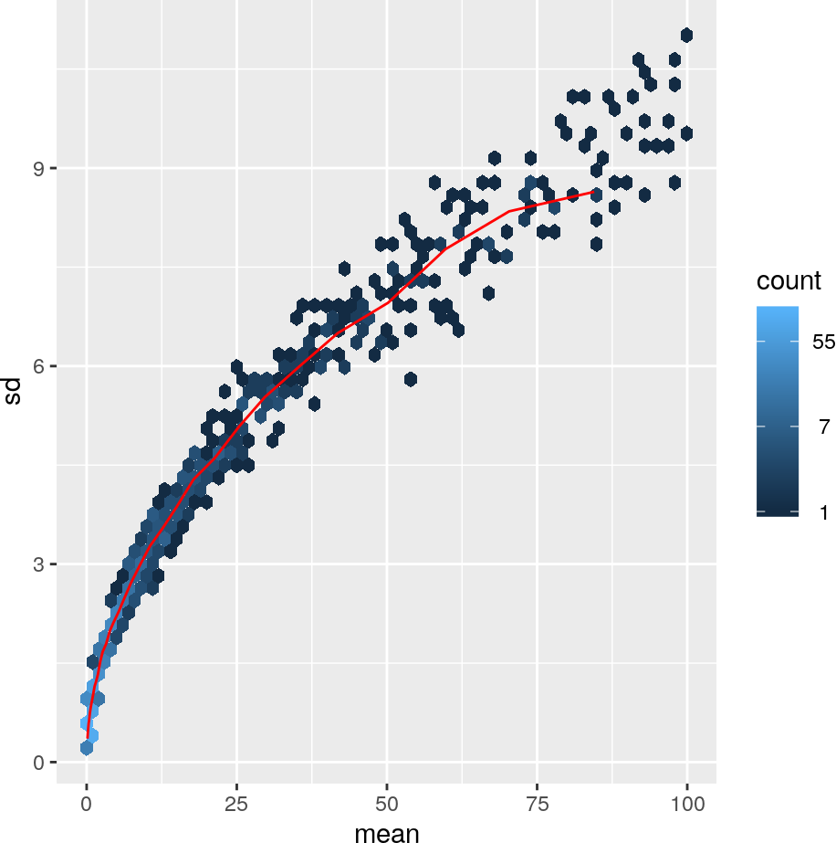

```r
lambda <- 10^seq(from = -1, to = 2, length = 1000)
cts <- matrix(rpois(1000*100, lambda), ncol = 100)
library("vsn")
meanSdPlot(cts, ranks = FALSE)
```

And for logarithm-transformed counts:

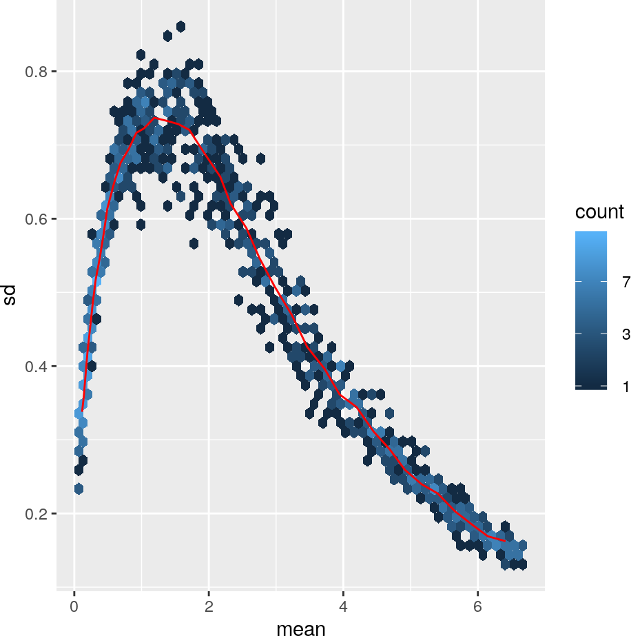

```r
log.cts.one <- log2(cts + 1)
meanSdPlot(log.cts.one, ranks = FALSE)
```

The logarithm with a small pseudocount amplifies differences when the values are close to 0. The low count genes with low signal-to-noise ratio will overly contribute to sample-sample distances and PCA plots.

As a solution, *DESeq2* offers two transformations for count data that stabilize the variance across the mean: the *variance stabilizing transformation* (VST) for negative binomial data with a dispersion-mean trend (Anders and Huber 2010), implemented in the *vst* function, and the *regularized-logarithm transformation* or *rlog* (Love, Huber, and Anders 2014).

For genes with high counts, both the VST and the rlog will give similar result to the ordinary log2 transformation of normalized counts. For genes with lower counts, however, the values are shrunken towards a middle value. The VST or rlog-transformed data then become approximately homoskedastic (more flat trend in the *meanSdPlot*), and can be used directly for computing distances between samples, making PCA plots, or as input to downstream methods which perform best with homoskedastic data.

**Which transformation to choose?** The VST is much faster to compute and is less sensitive to high count outliers than the rlog. The rlog tends to work well on small datasets (n < 30), potentially outperforming the VST when there is a wide range of sequencing depth across samples (an order of magnitude difference). We therefore recommend the VST for medium-to-large datasets (n > 30). You can perform both transformations and compare the `meanSdPlot` or PCA plots generated, as described below.

Note that the two transformations offered by DESeq2 are provided for applications *other* than differential testing. For differential testing we recommend the *DESeq* function applied to raw counts, as described later in this workflow, which also takes into account the dependence of the variance of counts on the mean value during the dispersion estimation step.

Both *vst* and *rlog* return a *DESeqTransform* object which is based on the *SummarizedExperiment* class. The transformed values are no longer counts, and are stored in the *assay* slot. The *colData* that was attached to `dds` is still accessible:

```r
vsd <- vst(dds, blind = FALSE)
head(assay(vsd), 3)
```

```
##                    SRR1039508 SRR1039509 SRR1039512 SRR1039513 SRR1039516
## ENSG00000000003.14  10.105781   9.852029  10.169726   9.991545  10.424865
## ENSG00000000419.12   9.692244   9.923647   9.801921   9.798653   9.763455
## ENSG00000000457.13   9.449592   9.312186   9.362754   9.459168   9.281415
##                    SRR1039517 SRR1039520 SRR1039521
## ENSG00000000003.14  10.194490  10.315814  10.002177
## ENSG00000000419.12   9.874703   9.683211   9.845507
## ENSG00000000457.13   9.395937   9.477971   9.477027
```

```r
colData(vsd)
```

```
## DataFrame with 8 rows and 5 columns
##                 names    donor     condition     cell      dex
##              <factor> <factor>      <factor> <factor> <factor>
## SRR1039508 SRR1039508   N61311     Untreated   N61311    untrt
## SRR1039509 SRR1039509   N61311 Dexamethasone   N61311      trt
## SRR1039512 SRR1039512  N052611     Untreated  N052611    untrt
## SRR1039513 SRR1039513  N052611 Dexamethasone  N052611      trt
## SRR1039516 SRR1039516  N080611     Untreated  N080611    untrt
## SRR1039517 SRR1039517  N080611 Dexamethasone  N080611      trt
## SRR1039520 SRR1039520  N061011     Untreated  N061011    untrt
## SRR1039521 SRR1039521  N061011 Dexamethasone  N061011      trt
```

Again, for the *rlog*:

```r
rld <- rlog(dds, blind = FALSE)
head(assay(rld), 3)
```

```
##                    SRR1039508 SRR1039509 SRR1039512 SRR1039513 SRR1039516
## ENSG00000000003.14   9.482613   9.172197   9.558383   9.346001   9.851349
## ENSG00000000419.12   8.860186   9.150196   9.000042   8.995902   8.951327
## ENSG00000000457.13   8.354790   8.166700   8.236582   8.366693   8.121781
##                    SRR1039517 SRR1039520 SRR1039521
## ENSG00000000003.14   9.587602   9.727248   9.357876
## ENSG00000000419.12   9.091075   8.848782   9.054384
## ENSG00000000457.13   8.282307   8.392384   8.391023
```

In the above function calls, we specified `blind = FALSE`, which means that differences between cell lines and treatment (the variables in the design) will not contribute to the expected variance-mean trend of the experiment. The experimental design is not used directly in the transformation, only in estimating the global amount of variability in the counts. For a fully *unsupervised* transformation, one can set `blind = TRUE` (which is the default).

To show the effect of the transformation, in the figure below we plot the first sample against the second, first simply using the *log2* function (after adding 1, to avoid taking the log of zero), and then using the VST and rlog-transformed values. For the *log2* approach, we need to first estimate *size factors* to account for sequencing depth, and then specify `normalized=TRUE`. Sequencing depth correction is done automatically for the *vst* and *rlog*.

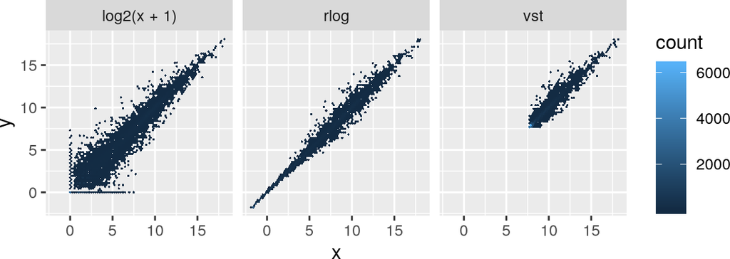

```r
library("dplyr")
library("ggplot2")

dds <- estimateSizeFactors(dds)

df <- bind_rows(
  as_data_frame(log2(counts(dds, normalized=TRUE)[, 1:2]+1)) %>%
         mutate(transformation = "log2(x + 1)"),
  as_data_frame(assay(vsd)[, 1:2]) %>% mutate(transformation = "vst"),
  as_data_frame(assay(rld)[, 1:2]) %>% mutate(transformation = "rlog"))

colnames(df)[1:2] <- c("x", "y")

ggplot(df, aes(x = x, y = y)) + geom_hex(bins = 80) +
  coord_fixed() + facet_grid( . ~ transformation)
```

We can see how genes with low counts (bottom left-hand corner) seem to be excessively variable on the ordinary logarithmic scale, while the VST and rlog compress differences for the low count genes for which the data provide little information about differential expression.

## 4.3 Sample distances

A useful first step in an RNA-seq analysis is often to assess overall similarity between samples: Which samples are similar to each other, which are different? Does this fit to the expectation from the experiment’s design?

We use the R function *dist* to calculate the Euclidean distance between samples. To ensure we have a roughly equal contribution from all genes, we use it on the VST data. We need to transpose the matrix of values using *t*, because the *dist* function expects the different samples to be rows of its argument, and different dimensions (here, genes) to be columns.

```r
sampleDists <- dist(t(assay(vsd)))
sampleDists
```

```
##            SRR1039508 SRR1039509 SRR1039512 SRR1039513 SRR1039516 SRR1039517
## SRR1039509   39.42362
## SRR1039512   32.37620   44.93748
## SRR1039513   51.09677   37.18799   41.79886
## SRR1039516   35.59642   47.54671   34.83458   52.05265
## SRR1039517   51.26314   41.58572   46.89609   40.67315   39.74268
## SRR1039520   32.38578   46.96000   30.35980   48.08669   37.07106   50.38349
## SRR1039521   51.49108   37.57383   47.17283   31.45899   52.62276   41.35941
##            SRR1039520
## SRR1039509
## SRR1039512
## SRR1039513
## SRR1039516
## SRR1039517
## SRR1039520
## SRR1039521   43.01502
```

We visualize the distances in a heatmap in a figure below, using the function *pheatmap* from the *pheatmap* package.

```r
library("pheatmap")
library("RColorBrewer")
```

In order to plot the sample distance matrix with the rows/columns arranged by the distances in our distance matrix, we manually provide `sampleDists` to the `clustering_distance` argument of the *pheatmap* function. Otherwise the *pheatmap* function would assume that the matrix contains the data values themselves, and would calculate distances between the rows/columns of the distance matrix, which is not desired. We also manually specify a blue color palette using the *colorRampPalette* function from the *RColorBrewer* package.

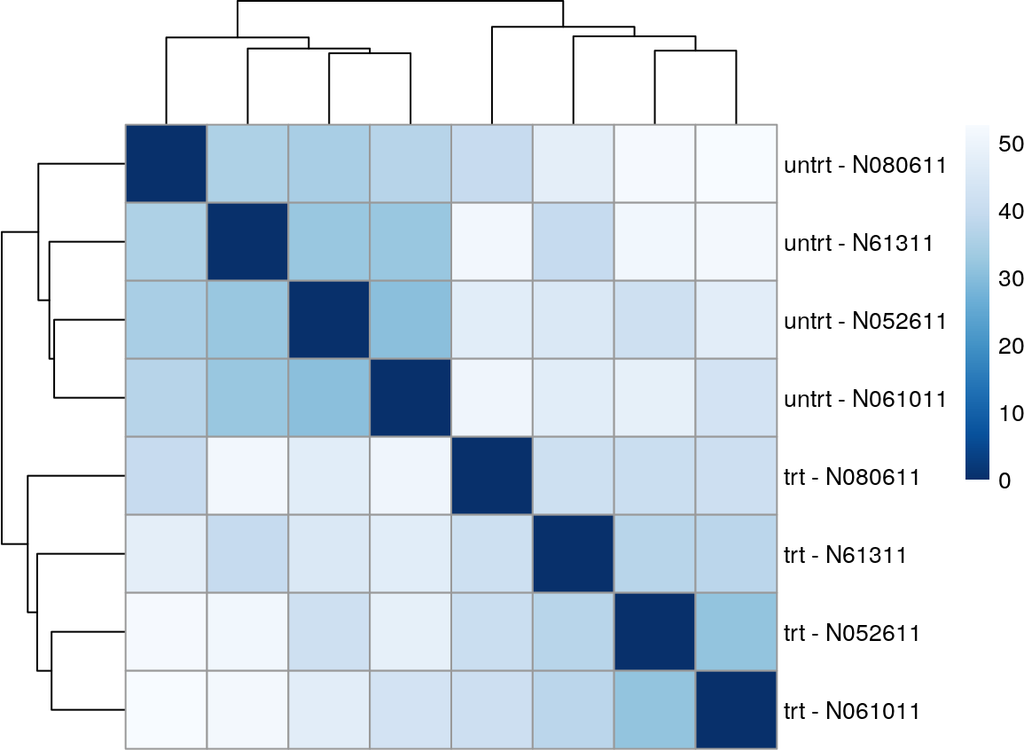

```r
sampleDistMatrix <- as.matrix( sampleDists )
rownames(sampleDistMatrix) <- paste( vsd$dex, vsd$cell, sep = " - " )
colnames(sampleDistMatrix) <- NULL
colors <- colorRampPalette( rev(brewer.pal(9, "Blues")) )(255)
pheatmap(sampleDistMatrix,
         clustering_distance_rows = sampleDists,
         clustering_distance_cols = sampleDists,
         col = colors)
```

**Heatmap of sample-to-sample distances using the variance stabilizing transformed values.**

Note that we have changed the row names of the distance matrix to contain treatment type and patient number instead of sample ID, so that we have all this information in view when looking at the heatmap.

Another option for calculating sample distances is to use the *Poisson Distance* (Witten 2011), implemented in the *PoiClaClu* package. This measure of dissimilarity between counts also takes the inherent variance structure of counts into consideration when calculating the distances between samples. The *PoissonDistance* function takes the original count matrix (not normalized) with samples as rows instead of columns, so we need to transpose the counts in `dds`.

```r
library("PoiClaClu")
poisd <- PoissonDistance(t(counts(dds)))
```

We plot the heatmap in a Figure below.

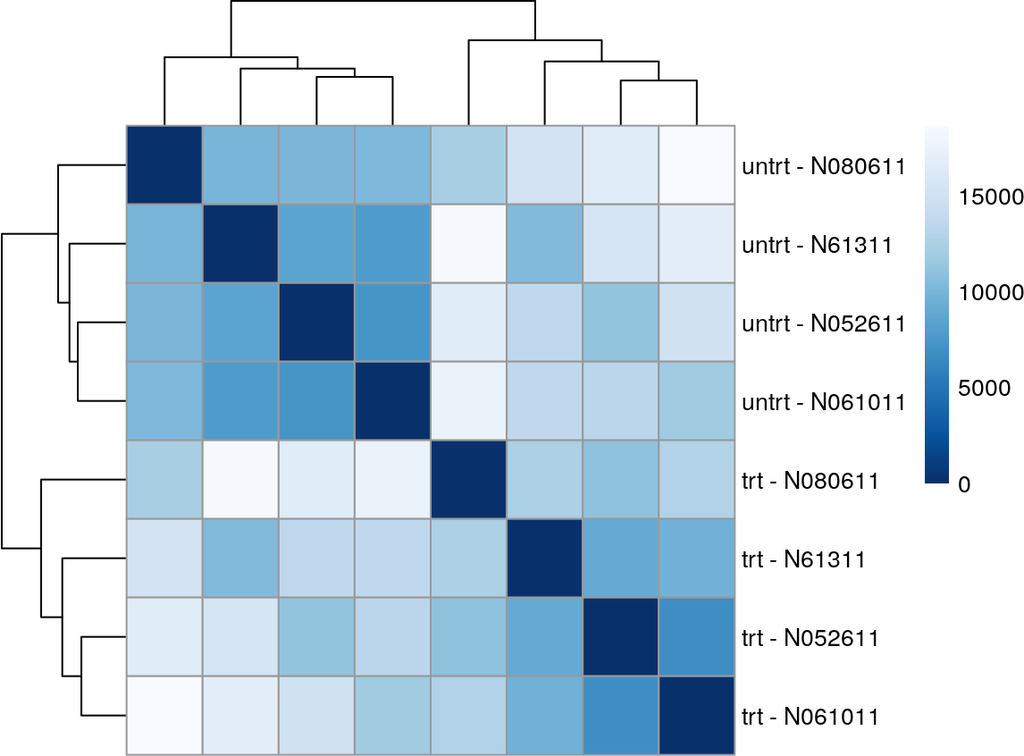

```r
samplePoisDistMatrix <- as.matrix( poisd$dd )
rownames(samplePoisDistMatrix) <- paste( dds$dex, dds$cell, sep=" - " )
colnames(samplePoisDistMatrix) <- NULL
pheatmap(samplePoisDistMatrix,
         clustering_distance_rows = poisd$dd,
         clustering_distance_cols = poisd$dd,
         col = colors)
```

**Heatmap of sample-to-sample distances using the *Poisson Distance*.**

## 4.4 PCA plot

Another way to visualize sample-to-sample distances is a principal components analysis (PCA). In this ordination method, the data points (here, the samples) are projected onto the 2D plane such that they spread out in the two directions that explain most of the differences (figure below). The x-axis is the direction that separates the data points the most. The values of the samples in this direction are written *PC1*. The y-axis is a direction (it must be *orthogonal* to the first direction) that separates the data the second most. The values of the samples in this direction are written *PC2*. The percent of the total variance that is contained in the direction is printed in the axis label. Note that these percentages do not add to 100%, because there are more dimensions that contain the remaining variance (although each of these remaining dimensions will explain less than the two that we see).

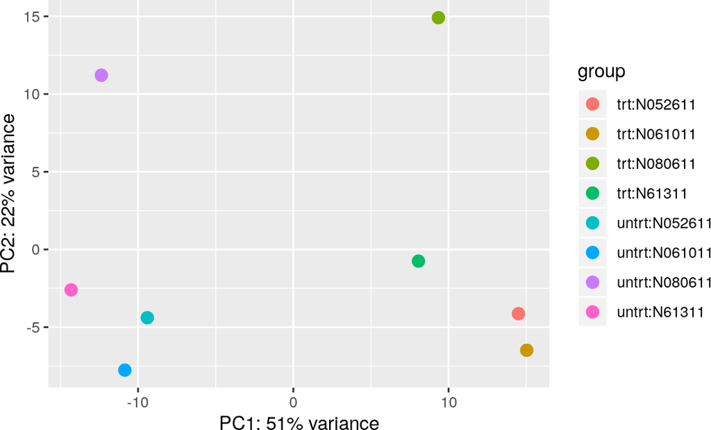

```r
plotPCA(vsd, intgroup = c("dex", "cell"))
```

**PCA plot using the VST data.** Each unique combination of treatment and cell line is given its own color.

Here, we have used the function *plotPCA* that comes with *DESeq2*. The two terms specified by `intgroup` are the interesting groups for labeling the samples; they tell the function to use them to choose colors. We can also build the PCA plot from scratch using the *ggplot2* package (Wickham 2009). This is done by asking the *plotPCA* function to return the data used for plotting rather than building the plot. See the *ggplot2* [documentation](http://docs.ggplot2.org/current/) for more details on using *ggplot*.

```r
pcaData <- plotPCA(vsd, intgroup = c( "dex", "cell"), returnData = TRUE)
pcaData
```

```
##                   PC1        PC2         group   dex    cell       name
## SRR1039508 -14.311369 -2.6000421  untrt:N61311 untrt  N61311 SRR1039508
## SRR1039509   8.058574 -0.7500532    trt:N61311   trt  N61311 SRR1039509
## SRR1039512  -9.404122 -4.3920761 untrt:N052611 untrt N052611 SRR1039512
## SRR1039513  14.497842 -4.1323833   trt:N052611   trt N052611 SRR1039513
## SRR1039516 -12.365055 11.2109581 untrt:N080611 untrt N080611 SRR1039516
## SRR1039517   9.343946 14.9115160   trt:N080611   trt N080611 SRR1039517
## SRR1039520 -10.852633 -7.7618618 untrt:N061011 untrt N061011 SRR1039520
## SRR1039521  15.032816 -6.4860576   trt:N061011   trt N061011 SRR1039521
```

```r
percentVar <- round(100 * attr(pcaData, "percentVar"))
```

We can then use these data to build up a second plot in a figure below, specifying that the color of the points should reflect dexamethasone treatment and the shape should reflect the cell line.

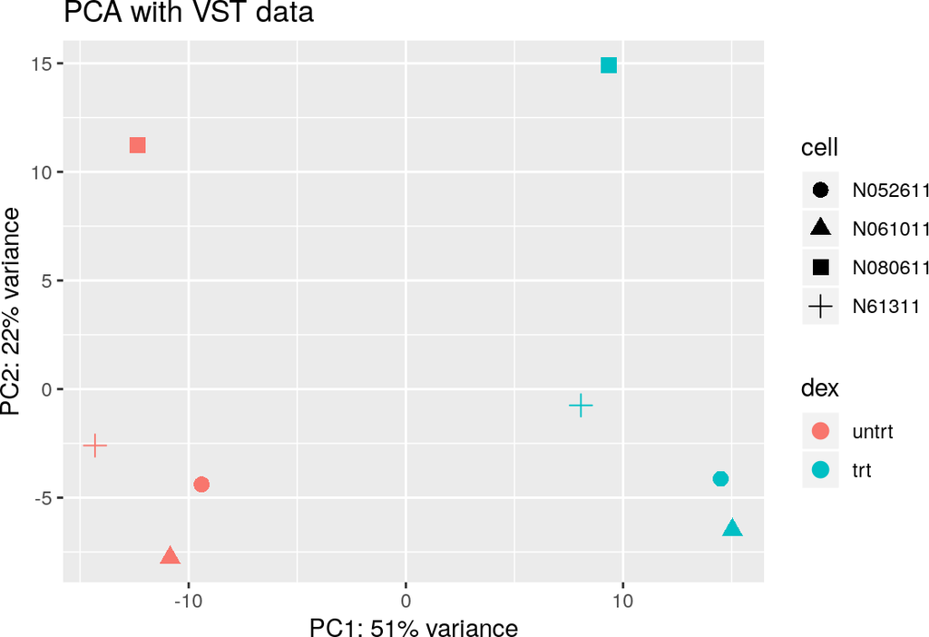

```r
ggplot(pcaData, aes(x = PC1, y = PC2, color = dex, shape = cell)) +
  geom_point(size =3) +
  xlab(paste0("PC1: ", percentVar[1], "% variance")) +
  ylab(paste0("PC2: ", percentVar[2], "% variance")) +
  coord_fixed() +
  ggtitle("PCA with VST data")
```

**PCA plot using the VST values with custom *ggplot2* code.** Here we specify cell line (plotting symbol) and dexamethasone treatment (color).

From the PCA plot, we see that the differences between cells (the different plotting shapes) are considerable, though not stronger than the differences due to treatment with dexamethasone (red vs blue color). This shows why it will be important to account for this in differential testing by using a paired design (“paired”, because each dex treated sample is paired with one untreated sample from the *same* cell line). We are already set up for this design by assigning the formula `~ cell + dex` earlier.

## 4.5 PCA plot using Generalized PCA

Another technique for performing dimension reduction on data that is not Normally distributed (e.g. over-dispersed count data) is *generalized principal component analysis*, or GLM-PCA, (Townes et al. 2019) as implemented in the CRAN package *glmpca*. This package takes as input the count matrix, as well as the number of latent dimensions to fit (here, we specify 2). As stated by Townes et al. (2019):

> …we propose the use of GLM-PCA, a generalization of PCA to exponential family likelihoods. GLM-PCA operates on raw counts, avoiding the pitfalls of normalization. We also demonstrate that applying PCA to deviance or Pearson residuals provides a useful and fast approximation to GLM-PCA.

```r
library("glmpca")
gpca <- glmpca(counts(dds), L=2)
gpca.dat <- gpca$factors
gpca.dat$dex <- dds$dex
gpca.dat$cell <- dds$cell
```

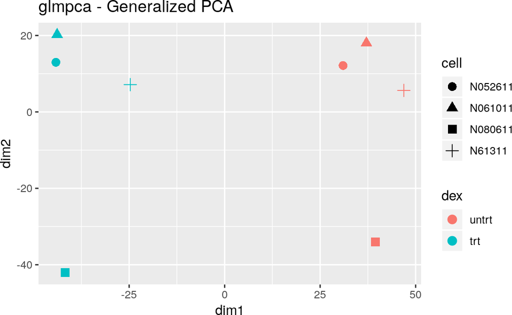

```r
ggplot(gpca.dat, aes(x = dim1, y = dim2, color = dex, shape = cell)) +
  geom_point(size =3) + coord_fixed() + ggtitle("glmpca - Generalized PCA")
```

## 4.6 MDS plot

Another plot, very similar to the PCA plot, can be made using the *multidimensional scaling* (MDS) function in base R. This is useful when we don’t have a matrix of data, but only a matrix of distances. Here we compute the MDS for the distances calculated from the *VST* data and plot these in a figure below.

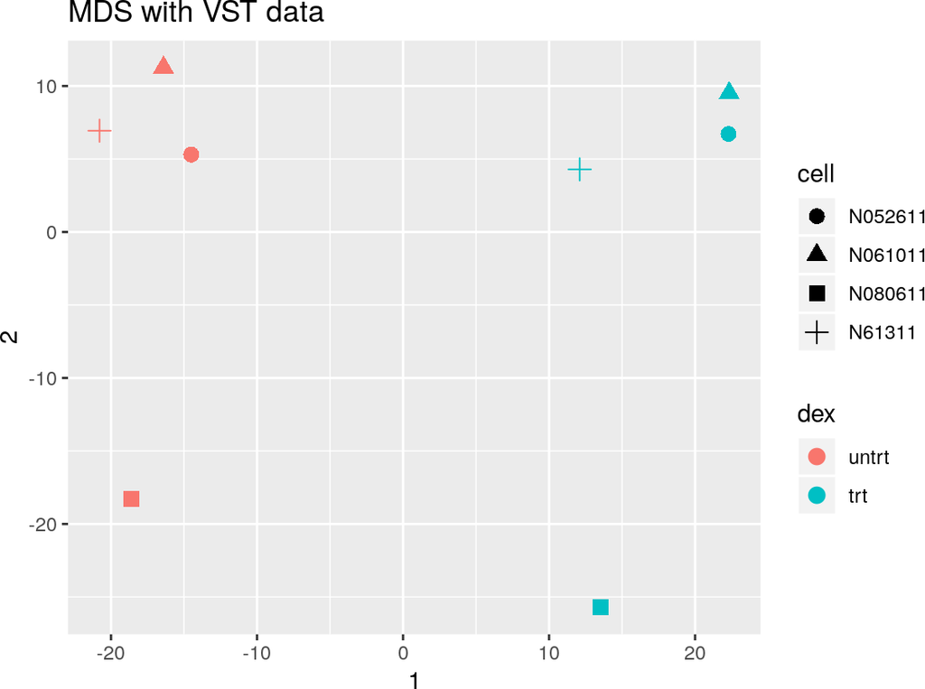

```r
mds <- as.data.frame(colData(vsd))  %>%
         cbind(cmdscale(sampleDistMatrix))
ggplot(mds, aes(x = `1`, y = `2`, color = dex, shape = cell)) +
  geom_point(size = 3) + coord_fixed() + ggtitle("MDS with VST data")
```

**MDS plot using VST data.**

In a figure below we show the same plot for the *PoissonDistance*:

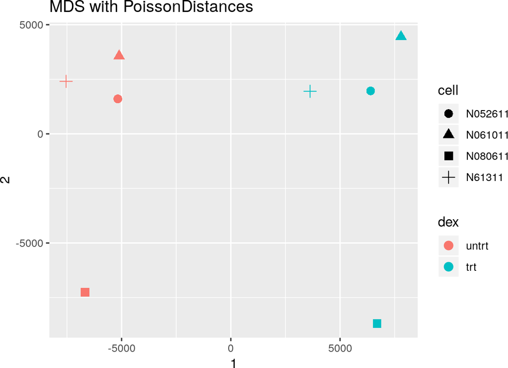

```r
mdsPois <- as.data.frame(colData(dds)) %>%
   cbind(cmdscale(samplePoisDistMatrix))
ggplot(mdsPois, aes(x = `1`, y = `2`, color = dex, shape = cell)) +
  geom_point(size = 3) + coord_fixed() + ggtitle("MDS with PoissonDistances")
```

**MDS plot using the *Poisson Distance*.**

# 5 Differential expression analysis

## 5.1 Running the differential expression pipeline

As we have already specified an experimental design when we created the *DESeqDataSet*, we can run the differential expression pipeline on the raw counts with a single call to the function *DESeq*:

```r
dds <- DESeq(dds)
```

This function will print out a message for the various steps it performs. These are described in more detail in the manual page for *DESeq*, which can be accessed by typing `?DESeq`. Briefly these are: the estimation of size factors (controlling for differences in the sequencing depth of the samples), the estimation of dispersion values for each gene, and fitting a generalized linear model.

A *DESeqDataSet* is returned that contains all the fitted parameters within it, and the following section describes how to extract out results tables of interest from this object.

## 5.2 Building the results table

Calling *results* without any arguments will extract the estimated log2 fold changes and *p* values for the last variable in the design formula. If there are more than 2 levels for this variable, *results* will extract the results table for a comparison of the last level over the first level. The comparison is printed at the top of the output: `dex trt vs untrt`.

```r
res <- results(dds)
res
```

```
## log2 fold change (MLE): dex trt vs untrt
## Wald test p-value: dex trt vs untrt
## DataFrame with 31604 rows and 6 columns
##                             baseMean      log2FoldChange             lfcSE
##                            <numeric>           <numeric>         <numeric>
## ENSG00000000003.14  739.940717372053  -0.361153676816704 0.106868570706217
## ENSG00000000419.12   511.73572199559   0.206314742225694 0.128664534265382
## ENSG00000000457.13  314.194855097564   0.037830765702789 0.158633410116225
## ENSG00000000460.16  79.7936215457165  -0.115258993162199 0.314990674190846
## ENSG00000000938.12 0.307266835513683   -1.36911852155525  3.50376358863452
## ...                              ...                 ...               ...
## ENSG00000285979.1   38.3538864147071   0.342365713888024 0.359510635836302
## ENSG00000285987.1   1.56250793343253   0.706414476454889   1.5472945399791
## ENSG00000285990.1  0.642314540619725   0.364733264633251  3.43327565299413
## ENSG00000285991.1   11.2762841129775  -0.116551517129412 0.748601160880117
## ENSG00000285994.1   3.65104108073599 -0.0960094332693204   1.0686598396981
##                                  stat               pvalue
##                             <numeric>            <numeric>
## ENSG00000000003.14  -3.37941898567652 0.000726392125305568
## ENSG00000000419.12   1.60350902759382    0.108822317644653
## ENSG00000000457.13  0.238479180867837    0.811509460868018
## ENSG00000000460.16 -0.365912398702847    0.714430444201867
## ENSG00000000938.12 -0.390756535628255    0.695977205170472
## ...                               ...                  ...
## ENSG00000285979.1   0.952310390182491    0.340939589953333
## ENSG00000285987.1   0.456548160807465    0.647995846834697
## ENSG00000285990.1   0.106234774453712    0.915396081024322
## ENSG00000285991.1  -0.155692407679924    0.876275481983982
## ENSG00000285994.1  -0.089840966884695    0.928413592935384
##                                   padj
##                              <numeric>
## ENSG00000000003.14 0.00531136916201363
## ENSG00000000419.12    0.29318869954709
## ENSG00000000457.13    0.92255697455246
## ENSG00000000460.16   0.872980377910416
## ENSG00000000938.12                  NA
## ...                                ...
## ENSG00000285979.1    0.600750489158647
## ENSG00000285987.1                   NA
## ENSG00000285990.1                   NA
## ENSG00000285991.1    0.952921308734728
## ENSG00000285994.1                   NA
```

We could have equivalently produced this results table with the following more specific command. Because `dex` is the last variable in the design, we could optionally leave off the `contrast` argument to extract the comparison of the two levels of `dex`.

```r
res <- results(dds, contrast=c("dex","trt","untrt"))
```

As `res` is a *DataFrame* object, it carries metadata with information on the meaning of the columns:

```r
mcols(res, use.names = TRUE)
```

```
## DataFrame with 6 rows and 2 columns
##                        type                               description
##                 <character>                               <character>
## baseMean       intermediate mean of normalized counts for all samples
## log2FoldChange      results  log2 fold change (MLE): dex trt vs untrt
## lfcSE               results          standard error: dex trt vs untrt
## stat                results          Wald statistic: dex trt vs untrt
## pvalue              results       Wald test p-value: dex trt vs untrt
## padj                results                      BH adjusted p-values
```

The first column, `baseMean`, is a just the average of the normalized count values, divided by the size factors, taken over all samples in the *DESeqDataSet*. The remaining four columns refer to a specific contrast, namely the comparison of the `trt` level over the `untrt` level for the factor variable `dex`. We will find out below how to obtain other contrasts.

The column `log2FoldChange` is the effect size estimate. It tells us how much the gene’s expression seems to have changed due to treatment with dexamethasone in comparison to untreated samples. This value is reported on a logarithmic scale to base 2: for example, a log2 fold change of 1.5 means that the gene’s expression is increased by a multiplicative factor of $2^{1.5} \approx 2.82$.

Of course, this estimate has an uncertainty associated with it, which is available in the column `lfcSE`, the standard error estimate for the log2 fold change estimate. We can also express the uncertainty of a particular effect size estimate as the result of a statistical test. The purpose of a test for differential expression is to test whether the data provides sufficient evidence to conclude that this value is really different from zero. *DESeq2* performs for each gene a *hypothesis test* to see whether evidence is sufficient to decide against the *null hypothesis* that there is zero effect of the treatment on the gene and that the observed difference between treatment and control was merely caused by experimental variability (i.e., the type of variability that you can expect between different samples in the same treatment group). As usual in statistics, the result of this test is reported as a *p* value, and it is found in the column `pvalue`. Remember that a *p* value indicates the probability that a fold change as strong as the observed one, or even stronger, would be seen under the situation described by the null hypothesis.

We can also summarize the results with the following line of code, which reports some additional information, that will be covered in later sections.

```r
summary(res)
```

```
##
## out of 31604 with nonzero total read count
## adjusted p-value < 0.1
## LFC > 0 (up)       : 2373, 7.5%
## LFC < 0 (down)     : 1949, 6.2%
## outliers [1]       : 0, 0%
## low counts [2]     : 14706, 47%
## (mean count < 9)
## [1] see 'cooksCutoff' argument of ?results
## [2] see 'independentFiltering' argument of ?results
```

Note that there are many genes with differential expression due to dexamethasone treatment at the FDR level of 10%. This makes sense, as the smooth muscle cells of the airway are known to react to glucocorticoid steroids. However, there are two ways to be more strict about which set of genes are considered significant:

- lower the false discovery rate threshold (the threshold on `padj` in the results table)
- raise the log2 fold change threshold from 0 using the `lfcThreshold` argument of *results*

If we lower the false discovery rate threshold, we should also inform the `results()` function about it, so that the function can use this threshold for the optimal independent filtering that it performs:

```r
res.05 <- results(dds, alpha = 0.05)
table(res.05$padj < 0.05)
```

```
##
## FALSE  TRUE
## 13357  3541
```

If we want to raise the log2 fold change threshold, so that we test for genes that show more substantial changes due to treatment, we simply supply a value on the log2 scale. For example, by specifying `lfcThreshold = 1`, we test for genes that show significant effects of treatment on gene counts more than doubling or less than halving, because $2^1 = 2$.

```r
resLFC1 <- results(dds, lfcThreshold=1)
table(resLFC1$padj < 0.1)
```

```
##
## FALSE  TRUE
## 16687   211
```

Sometimes a subset of the *p* values in `res` will be `NA` (“not available”). This is *DESeq*’s way of reporting that all counts for this gene were zero, and hence no test was applied. In addition, *p* values can be assigned `NA` if the gene was excluded from analysis because it contained an extreme count outlier. For more information, see the outlier detection section of the *DESeq2* vignette.

If you use the results from an R analysis package in published research, you can find the proper citation for the software by typing `citation("pkgName")`, where you would substitute the name of the package for `pkgName`. Citing methods papers helps to support and reward the individuals who put time into open source software for genomic data analysis.

## 5.3 Other comparisons

In general, the results for a comparison of any two levels of a variable can be extracted using the `contrast` argument to *results*. The user should specify three values: the name of the variable, the name of the level for the numerator, and the name of the level for the denominator. Here we extract results for the log2 of the fold change of one cell line over another:

```r
results(dds, contrast = c("cell", "N061011", "N61311"))
```

```
## log2 fold change (MLE): cell N061011 vs N61311
## Wald test p-value: cell N061011 vs N61311
## DataFrame with 31604 rows and 6 columns
##                             baseMean      log2FoldChange             lfcSE
##                            <numeric>           <numeric>         <numeric>
## ENSG00000000003.14  739.940717372053   0.270945073288709 0.152170652747702
## ENSG00000000419.12   511.73572199559 -0.0718309515716052 0.182816709211393
## ENSG00000000457.13  314.194855097564    0.17988057135378 0.225122028264875
## ENSG00000000460.16  79.7936215457165  -0.119482058987533 0.441593831219506
## ENSG00000000938.12 0.307266835513683                   0   4.9975798104491
## ...                              ...                 ...               ...
## ENSG00000285979.1   38.3538864147071  0.0589757126275791  0.51239142744962
## ENSG00000285987.1   1.56250793343253    1.02168042060967  2.20186060481305
## ENSG00000285990.1  0.642314540619725   -3.09564035666317  4.85271500898552
## ENSG00000285991.1   11.2762841129775  -0.877962796217153  1.04696318967239
## ENSG00000285994.1   3.65104108073599 -0.0192350857348909   1.5132364065081
##                                   stat             pvalue              padj
##                              <numeric>          <numeric>         <numeric>
## ENSG00000000003.14    1.78053434349088 0.0749885539964633 0.378827680439035
## ENSG00000000419.12   -0.39291239778606  0.694384184390241 0.936703409285515
## ENSG00000000457.13   0.799035850646014  0.424269624416598 0.820732883668396
## ENSG00000000460.16  -0.270570036401033  0.786721743935893 0.960661528779669
## ENSG00000000938.12                   0                  1                NA
## ...                                ...                ...               ...
## ENSG00000285979.1    0.115098944806952  0.908366696268638 0.983709901493367
## ENSG00000285987.1     0.46400776614849  0.642642181542788                NA
## ENSG00000285990.1   -0.637919257762125  0.523526241080306                NA
## ENSG00000285991.1   -0.838580386471737   0.40170482075606                NA
## ENSG00000285994.1  -0.0127112232114989  0.989858184362336                NA
```

There are additional ways to build results tables for certain comparisons after running *DESeq* once. If results for an interaction term are desired, the `name` argument of *results* should be used. Please see the help page for the *results* function for details on the additional ways to build results tables. In particular, the **Examples** section of the help page for *results* gives some pertinent examples.

## 5.4 Multiple testing

In high-throughput biology, we are careful to not use the *p* values directly as evidence against the null, but to correct for *multiple testing*. What would happen if we were to simply threshold the *p* values at a low value, say 0.05? There are 5170 genes with a *p* value below 0.05 among the 31604 genes for which the test succeeded in reporting a *p* value:

```r
sum(res$pvalue < 0.05, na.rm=TRUE)
```

```
## [1] 5170
```

```r
sum(!is.na(res$pvalue))
```

```
## [1] 31604
```

Now, assume for a moment that the null hypothesis is true for all genes, i.e., no gene is affected by the treatment with dexamethasone. Then, by the definition of the *p* value, we expect up to 5% of the genes to have a *p* value below 0.05. This amounts to 1580 genes. If we just considered the list of genes with a *p* value below 0.05 as differentially expressed, this list should therefore be expected to contain up to 1580 / 5170 = 31% false positives.

*DESeq2* uses the Benjamini-Hochberg (BH) adjustment (Benjamini and Hochberg 1995) as implemented in the base R *p.adjust* function; in brief, this method calculates for each gene an adjusted *p* value that answers the following question: if one called significant all genes with an adjusted *p* value less than or equal to this gene’s adjusted *p* value threshold, what would be the fraction of false positives (the *false discovery rate*, FDR) among them, in the sense of the calculation outlined above? These values, called the BH-adjusted *p* values, are given in the column `padj` of the `res` object.

The FDR is a useful statistic for many high-throughput experiments, as we are often interested in reporting or focusing on a set of interesting genes, and we would like to put an upper bound on the percent of false positives in this set.

Hence, if we consider a fraction of 10% false positives acceptable, we can consider all genes with an adjusted *p* value below 10% = 0.1 as significant. How many such genes are there?

```r
sum(res$padj < 0.1, na.rm=TRUE)
```

```
## [1] 4322
```

We subset the results table to these genes and then sort it by the log2 fold change estimate to get the significant genes with the strongest down-regulation:

```r
resSig <- subset(res, padj < 0.1)
head(resSig[ order(resSig$log2FoldChange), ])
```

```
## log2 fold change (MLE): dex trt vs untrt
## Wald test p-value: dex trt vs untrt
## DataFrame with 6 rows and 6 columns
##                           baseMean    log2FoldChange             lfcSE
##                          <numeric>         <numeric>         <numeric>
## ENSG00000216490.3 42.3007106248874 -5.72482604043858  1.47565155349927
## ENSG00000267339.5 30.5206063861615 -5.39781111590036 0.773017198758288
## ENSG00000257542.5 10.0398869404764 -5.25991351125893  1.28200100388257
## ENSG00000146006.7 61.6448430808005 -4.49504194549369 0.663821044679587
## ENSG00000108700.4 14.6323552674909 -4.09068745839218 0.941842256424086
## ENSG00000213240.8  12.096158074824 -3.87312575409988  1.27413298748988
##                                stat               pvalue
##                           <numeric>            <numeric>
## ENSG00000216490.3 -3.87952428665362 0.000104660951388532
## ENSG00000267339.5 -6.98278269173179 2.89389866967638e-12
## ENSG00000257542.5 -4.10289344183752 4.08015195589968e-05
## ENSG00000146006.7 -6.77146646904417 1.27483509915651e-11
## ENSG00000108700.4 -4.34328299722226 1.40369125072207e-05
## ENSG00000213240.8 -3.03981279201488  0.00236725244353312
##                                   padj
##                              <numeric>
## ENSG00000216490.3 0.000987852735619452
## ENSG00000267339.5  9.4586266383349e-11
## ENSG00000257542.5 0.000430645894758231
## ENSG00000146006.7 3.82631678606515e-10
## ENSG00000108700.4  0.00016668710298455
## ENSG00000213240.8   0.0144986704569854
```

…and with the strongest up-regulation:

```r
head(resSig[ order(resSig$log2FoldChange, decreasing = TRUE), ])
```

```
## log2 fold change (MLE): dex trt vs untrt
## Wald test p-value: dex trt vs untrt
## DataFrame with 6 rows and 6 columns
##                            baseMean   log2FoldChange             lfcSE
##                           <numeric>        <numeric>         <numeric>
## ENSG00000254692.1  62.2302142486739 10.2071429096331  3.37705826771585
## ENSG00000179593.15 67.0895286534166 9.50514812098004  1.07705493413338
## ENSG00000268173.3  46.4370434386407 8.40438119076897  3.38505617991746
## ENSG00000224712.12 35.5607475035812 7.16685536619654  2.16475512121352
## ENSG00000109906.13 438.193981971508    6.37749569519 0.313810468763181
## ENSG00000257663.1  24.3946124843467 6.34758399422488  2.09531382411201
##                                stat               pvalue
##                           <numeric>            <numeric>
## ENSG00000254692.1   3.0224953496396  0.00250699934752643
## ENSG00000179593.15 8.82512843100996 1.09334265101889e-18
## ENSG00000268173.3  2.48278927854424   0.0130358175653821
## ENSG00000224712.12  3.3107002708828 0.000930628316571692
## ENSG00000109906.13 20.3227627182917 8.08933590300385e-92
## ENSG00000257663.1  3.02941923122899  0.00245024410719956
##                                    padj
##                               <numeric>
## ENSG00000254692.1    0.0152166935971629
## ENSG00000179593.15 6.81745539369636e-17
## ENSG00000268173.3    0.0594385443118797
## ENSG00000224712.12  0.00655239887226186
## ENSG00000109906.13 1.24266907353599e-88
## ENSG00000257663.1    0.0149150666150786
```

# 6 Plotting results

## 6.1 Counts plot

A quick way to visualize the counts for a particular gene is to use the *plotCounts* function that takes as arguments the *DESeqDataSet*, a gene name, and the group over which to plot the counts (figure below).

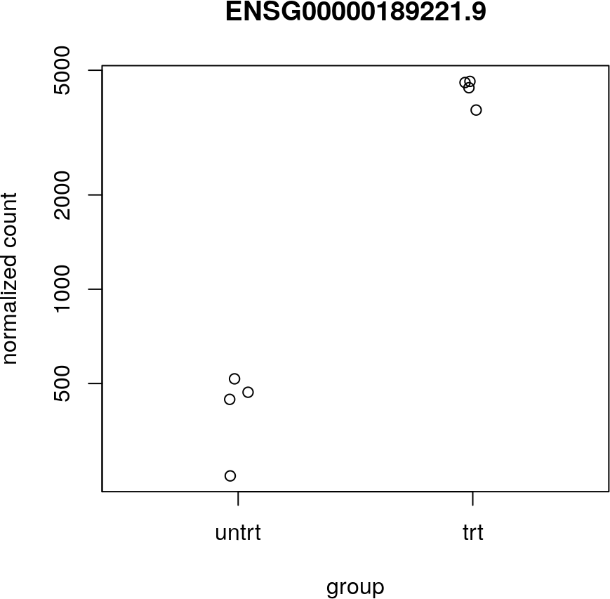

```r
topGene <- rownames(res)[which.min(res$padj)]
plotCounts(dds, gene = topGene, intgroup=c("dex"))
```

**Normalized counts for a single gene over treatment group.**

We can also make custom plots using the *ggplot* function from the *ggplot2* package (figures below).

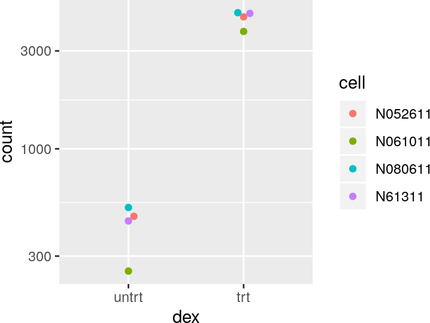

```r
library("ggbeeswarm")
geneCounts <- plotCounts(dds, gene = topGene, intgroup = c("dex","cell"),
                         returnData = TRUE)
ggplot(geneCounts, aes(x = dex, y = count, color = cell)) +
  scale_y_log10() +  geom_beeswarm(cex = 3)
```

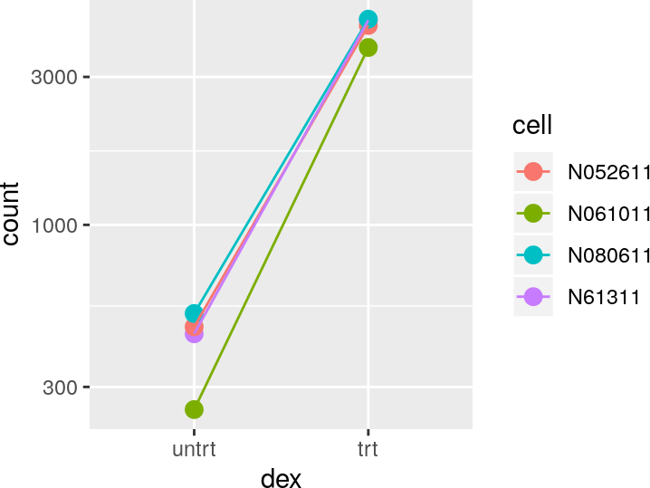

```r
ggplot(geneCounts, aes(x = dex, y = count, color = cell, group = cell)) +
  scale_y_log10() + geom_point(size = 3) + geom_line()
```

**Normalized counts with lines connecting cell lines.** Note that the *DESeq* test actually takes into account the cell line effect, so this figure more closely depicts the difference being tested.

## 6.2 MA-plot

An *MA-plot* (Dudoit et al. 2002) provides a useful overview for the distribution of the estimated coefficients in the model, e.g. the comparisons of interest, across all genes. On the y-axis, the “M” stands for “minus” – subtraction of log values is equivalent to the log of the ratio – and on the x-axis, the “A” stands for “average”. You may hear this plot also referred to as a mean-difference plot, or a Bland-Altman plot.

Before making the MA-plot, we use the *lfcShrink* function to shrink the log2 fold changes for the comparison of dex treated vs untreated samples. There are three types of shrinkage estimators in *DESeq2*, which are covered in the [DESeq2 vignette](https://bioconductor.org/packages/release/bioc/vignettes/DESeq2/inst/doc/DESeq2.html). Here we specify the *apeglm* method for shrinking coefficients, which is good for shrinking the noisy LFC estimates while giving low bias LFC estimates for true large differences (Zhu, Ibrahim, and Love 2018). To use *apeglm* we specify a coefficient from the model to shrink, either by name or number as the coefficient appears in `resultsNames(dds)`.

```r
library("apeglm")
resultsNames(dds)
```

```
## [1] "Intercept"               "cell_N061011_vs_N052611"
## [3] "cell_N080611_vs_N052611" "cell_N61311_vs_N052611"
## [5] "dex_trt_vs_untrt"
```

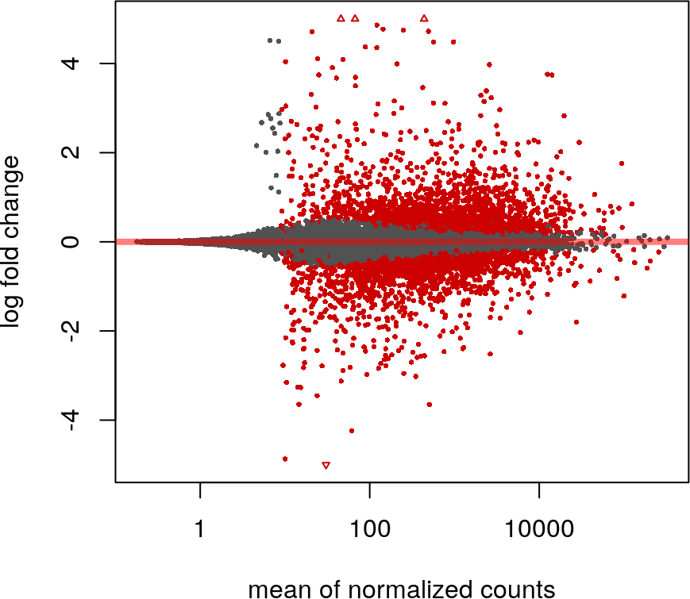

```r
res <- lfcShrink(dds, coef="dex_trt_vs_untrt", type="apeglm")
plotMA(res, ylim = c(-5, 5))
```

If it is necessary to specify a contrast not represented in `resultsNames(dds)`, either of the other two shrinkage methods can be used, or in some cases, re-factoring the relevant variables and running `nbinomWaldTest` followed by `lfcShrink` is sufficient. See the DESeq2 vignette for more details.

**An MA-plot of changes induced by treatment.** The log2 fold change for a particular comparison is plotted on the y-axis and the average of the counts normalized by size factor is shown on the x-axis. Each gene is represented with a dot. Genes with an adjusted *p* value below a threshold (here 0.1, the default) are shown in red.

The *DESeq2* package uses a Bayesian procedure to moderate (or “shrink”) log2 fold changes from genes with very low counts and highly variable counts, as can be seen by the narrowing of the vertical spread of points on the left side of the MA-plot. As shown above, the *lfcShrink* function performs this operation. For a detailed explanation of the rationale of moderated fold changes, please see the *DESeq2* paper (Love, Huber, and Anders 2014).

If we had not used statistical moderation to shrink the noisy log2 fold changes, we would have instead seen the following plot:

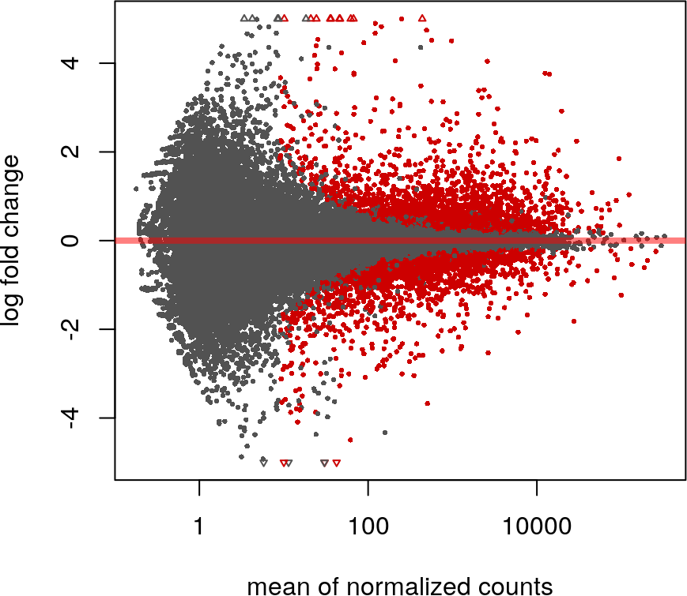

```r
res.noshr <- results(dds, name="dex_trt_vs_untrt")
plotMA(res.noshr, ylim = c(-5, 5))
```

We can label individual points on the MA-plot as well. Here we use the *with* R function to plot a circle and text for a selected row of the results object. Within the *with* function, only the `baseMean` and `log2FoldChange` values for the selected rows of `res` are used.

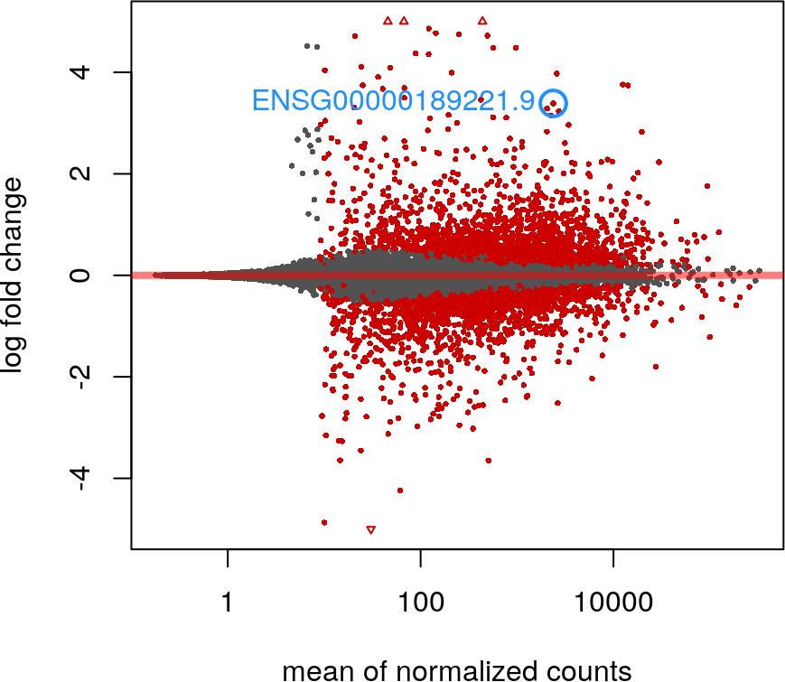

```r
plotMA(res, ylim = c(-5,5))
topGene <- rownames(res)[which.min(res$padj)]
with(res[topGene, ], {
  points(baseMean, log2FoldChange, col="dodgerblue", cex=2, lwd=2)
  text(baseMean, log2FoldChange, topGene, pos=2, col="dodgerblue")
})
```

Another useful diagnostic plot is the histogram of the *p* values (figure below). This plot is best formed by excluding genes with very small counts, which otherwise generate spikes in the histogram.

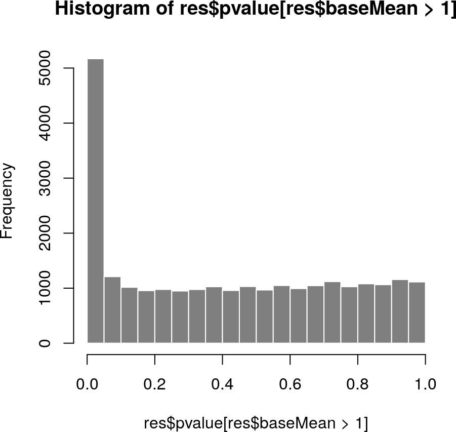

```r
hist(res$pvalue[res$baseMean > 1], breaks = 0:20/20,
     col = "grey50", border = "white")
```

**Histogram of *p* values for genes with mean normalized count larger than 1.**

## 6.3 Gene clustering

In the sample distance heatmap made previously, the dendrogram at the side shows us a hierarchical clustering of the samples. Such a clustering can also be performed for the genes. Since the clustering is only relevant for genes that actually carry a signal, one usually would only cluster a subset of the most highly variable genes. Here, for demonstration, let us select the 20 genes with the highest variance across samples. We will work with the VST data.

```r
library("genefilter")
topVarGenes <- head(order(rowVars(assay(vsd)), decreasing = TRUE), 20)
```

The heatmap becomes more interesting if we do not look at absolute expression strength but rather at the amount by which each gene deviates in a specific sample from the gene’s average across all samples. Hence, we center each genes’ values across samples, and plot a heatmap (figure below). We provide a *data.frame* that instructs the *pheatmap* function how to label the columns.

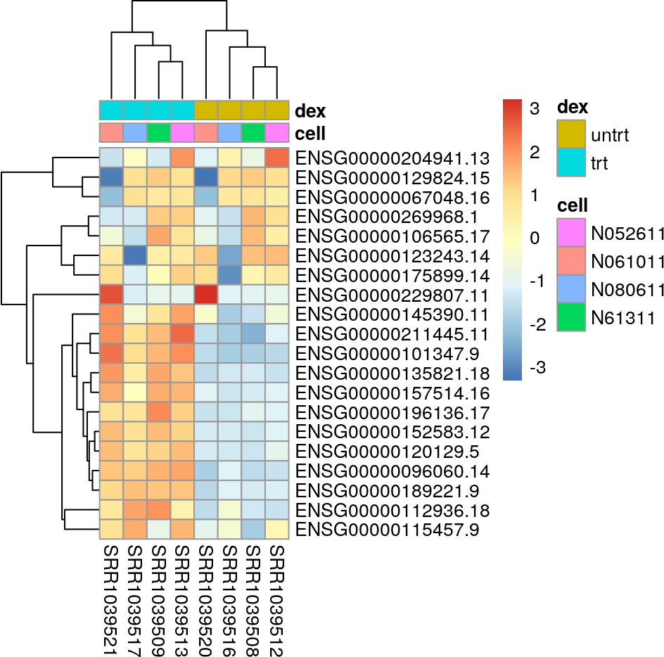

```r
mat  <- assay(vsd)[ topVarGenes, ]
mat  <- mat - rowMeans(mat)
anno <- as.data.frame(colData(vsd)[, c("cell","dex")])
pheatmap(mat, annotation_col = anno)
```

**Heatmap of relative VST-transformed values across samples.** Treatment status and cell line information are shown with colored bars at the top of the heatmap. Blocks of genes that covary across patients. Note that a set of genes in the heatmap are separating the N061011 cell line from the others, and there is another set of genes for which the dexamethasone treated samples have higher gene expression.

## 6.4 Independent filtering

The MA plot highlights an important property of RNA-seq data. For weakly expressed genes, we have no chance of seeing differential expression, because the low read counts suffer from such high Poisson noise that any biological effect is drowned in the uncertainties from the sampling at a low rate. We can also show this by examining the ratio of small *p* values (say, less than 0.05) for genes binned by mean normalized count. We will use the results table subjected to the threshold to show what this looks like in a case when there are few tests with small *p* value.

In the following code chunk, we create bins using the *quantile* function, bin the genes by base mean using *cut*, rename the levels of the bins using the middle point, calculate the ratio of *p* values less than 0.05 for each bin, and finally plot these ratios (figure below).

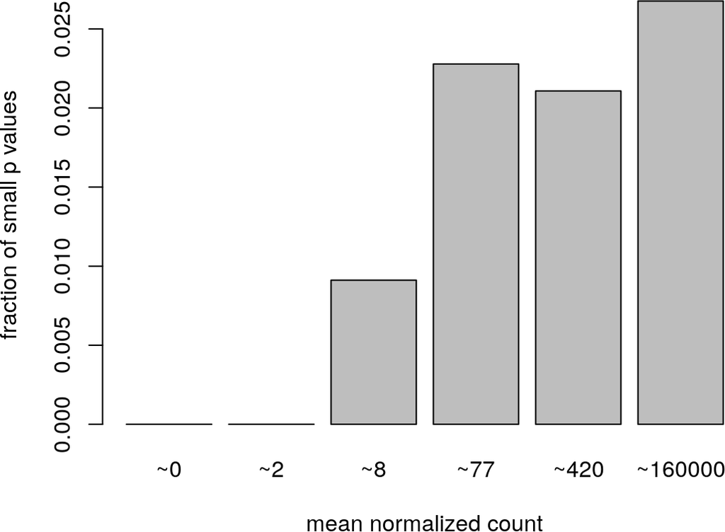

```r
qs <- c(0, quantile(resLFC1$baseMean[resLFC1$baseMean > 0], 0:6/6))
bins <- cut(resLFC1$baseMean, qs)
levels(bins) <- paste0("~", round(signif((qs[-1] + qs[-length(qs)])/2, 2)))
fractionSig <- tapply(resLFC1$pvalue, bins, function(p)
                          mean(p < .05, na.rm = TRUE))
barplot(fractionSig, xlab = "mean normalized count",
                     ylab = "fraction of small p values")
```

**The ratio of small *p* values for genes binned by mean normalized count.** The *p* values are from a test of log2 fold change greater than 1 or less than -1. This plot demonstrates that genes with very low mean count have little or no power, and are best excluded from testing.

At first sight, there may seem to be little benefit in filtering out these genes. After all, the test found them to be non-significant anyway. However, these genes have an influence on the multiple testing adjustment, whose performance improves if such genes are removed. By removing the low count genes from the input to the FDR procedure, we can find more genes to be significant among those that we keep, and so improved the power of our test. This approach is known as *independent filtering*.

The *DESeq2* software automatically performs independent filtering that maximizes the number of genes with adjusted *p* value less than a critical value (by default, `alpha` is set to 0.1). This automatic independent filtering is performed by, and can be controlled by, the *results* function.

The term *independent* highlights an important caveat. Such filtering is permissible only if the statistic that we filter on (here the mean of normalized counts across all samples) is independent of the actual test statistic (the *p* value) under the null hypothesis. Otherwise, the filtering would invalidate the test and consequently the assumptions of the BH procedure. The independent filtering software used inside *DESeq2* comes from the *genefilter* package, that contains a reference to a paper describing the statistical foundation for independent filtering (Bourgon, Gentleman, and Huber 2010).

## 6.5 Independent Hypothesis Weighting

A generalization of the idea of *p* value filtering is to *weight* hypotheses to optimize power. A Bioconductor package, *IHW* is available that implements the method of *Independent Hypothesis Weighting* (Ignatiadis et al. 2016). See the *DESeq2* package vignette for an example of using *IHW* in combination with *DESeq2*. In particular, the following (here, un-evaluated) code chunk can be used to perform IHW in lieu of independent filtering described above.

```r
library("IHW")
res.ihw <- results(dds, filterFun=ihw)
```

# 7 Annotating and exporting results

Our result table so far only contains the Ensembl gene IDs, but alternative gene names may be more informative for interpretation. Bioconductor’s annotation packages help with mapping various ID schemes to each other. We load the *AnnotationDbi* package and the annotation package *org.Hs.eg.db*:

```r
library("AnnotationDbi")
library("org.Hs.eg.db")
```

This is the organism annotation package (“org”) for *Homo sapiens* (“Hs”), organized as an *AnnotationDbi* database package (“db”), using Entrez Gene IDs (“eg”) as primary key. To get a list of all available key types, use:

```r
columns(org.Hs.eg.db)
```

```
##  [1] "ACCNUM"       "ALIAS"        "ENSEMBL"      "ENSEMBLPROT"
##  [5] "ENSEMBLTRANS" "ENTREZID"     "ENZYME"       "EVIDENCE"
##  [9] "EVIDENCEALL"  "GENENAME"     "GO"           "GOALL"
## [13] "IPI"          "MAP"          "OMIM"         "ONTOLOGY"
## [17] "ONTOLOGYALL"  "PATH"         "PFAM"         "PMID"
## [21] "PROSITE"      "REFSEQ"       "SYMBOL"       "UCSCKG"
## [25] "UNIGENE"      "UNIPROT"
```

We can use the *mapIds* function to add individual columns to our results table. We provide the row names of our results table as a key, and specify that `keytype=ENSEMBL`. The `column` argument tells the *mapIds* function which information we want, and the `multiVals` argument tells the function what to do if there are multiple possible values for a single input value. Here we ask to just give us back the first one that occurs in the database. To add the gene symbol and Entrez ID, we call *mapIds* twice.

```r
ens.str <- substr(rownames(res), 1, 15)
res$symbol <- mapIds(org.Hs.eg.db,
                     keys=ens.str,
                     column="SYMBOL",
                     keytype="ENSEMBL",
                     multiVals="first")
res$entrez <- mapIds(org.Hs.eg.db,
                     keys=ens.str,
                     column="ENTREZID",
                     keytype="ENSEMBL",
                     multiVals="first")
```

Now the results have the desired external gene IDs:

```r
resOrdered <- res[order(res$pvalue),]
head(resOrdered)
```

```
## log2 fold change (MAP): dex trt vs untrt
## Wald test p-value: dex trt vs untrt
## DataFrame with 6 rows and 7 columns
##                            baseMean   log2FoldChange             lfcSE
##                           <numeric>        <numeric>         <numeric>
## ENSG00000189221.9  2373.80530666857 3.38765439100121 0.136984725340923
## ENSG00000120129.5  3420.72722668767 2.96334836319583 0.120849818517184
## ENSG00000101347.9  14125.5841210142 3.74129175571401 0.157926779740683
## ENSG00000196136.17 2710.21742603852 3.23518345105418  0.14395099611165
## ENSG00000152583.12 974.737366684742 4.48640613542984 0.201275651988895
## ENSG00000211445.11 12512.7915263227 3.75874563219012 0.169535830279303
##                                   pvalue                  padj      symbol
##                                <numeric>             <numeric> <character>
## ENSG00000189221.9  1.84493931070439e-137 3.11757844722828e-133        MAOA
## ENSG00000120129.5  6.35042375935875e-135  5.3654730342822e-131       DUSP1
## ENSG00000101347.9  2.88983300389189e-127 1.62774660332551e-123      SAMHD1
## ENSG00000196136.17 3.68488166765799e-114 1.55667826050212e-110    SERPINA3
## ENSG00000152583.12 2.94551443786032e-113 9.95466059419273e-110     SPARCL1
## ENSG00000211445.11 2.36246306536582e-112 6.65348347975861e-109        GPX3
##                         entrez
##                    <character>
## ENSG00000189221.9         4128
## ENSG00000120129.5         1843
## ENSG00000101347.9        25939
## ENSG00000196136.17          12
## ENSG00000152583.12        8404
## ENSG00000211445.11        2878
```

## 7.1 Exporting results

You can easily save the results table in a CSV file that you can then share or load with a spreadsheet program such as Excel. The call to *as.data.frame* is necessary to convert the *DataFrame* object (*IRanges* package) to a *data.frame* object that can be processed by *write.csv*. Here, we take just the top 100 genes for demonstration.

```r
resOrderedDF <- as.data.frame(resOrdered)[1:100, ]
write.csv(resOrderedDF, file = "results.csv")
```

A more sophisticated way for exporting results the Bioconductor package *ReportingTools* (Huntley et al. 2013). *ReportingTools* will automatically generate dynamic HTML documents, including links to external databases using gene identifiers and boxplots summarizing the normalized counts across groups. See the *ReportingTools* vignettes for full details. The simplest version of creating a dynamic *ReportingTools* report is performed with the following code:

```r
library("ReportingTools")
htmlRep <- HTMLReport(shortName="report", title="My report",
                      reportDirectory="./report")
publish(resOrderedDF, htmlRep)
url <- finish(htmlRep)
browseURL(url)
```

## 7.2 Plotting fold changes in genomic space

If we have used the *tximeta* function to read in the quantification data, then our *DESeqDataSet* object is built on top of ready-to-use Bioconductor objects specifying the genomic coordinates of the genes. We can therefore easily plot our differential expression results in genomic space. While the *results* or *lfcShrink* functions by default return a *DataFrame*, using the `format` argument, we can ask for *GRanges* or *GRangesList* output (the latter is only possible if we use the *addExons* function from the *tximeta* package upstream of creating a *DESeqDataSet*).

```r
resGR <- lfcShrink(dds, coef="dex_trt_vs_untrt", type="apeglm", format="GRanges")
resGR
```

```
## GRanges object with 31604 ranges and 5 metadata columns:
##                      seqnames              ranges strand |          baseMean
##                         <Rle>           <IRanges>  <Rle> |         <numeric>
##   ENSG00000000003.14     chrX 100627109-100639991      - |  739.940717372053
##   ENSG00000000419.12    chr20   50934867-50958555      - |   511.73572199559
##   ENSG00000000457.13     chr1 169849631-169894267      - |  314.194855097564
##   ENSG00000000460.16     chr1 169662007-169854080      + |  79.7936215457165
##   ENSG00000000938.12     chr1   27612064-27635277      - | 0.307266835513683
##                  ...      ...                 ...    ... .               ...
##    ENSG00000285979.1    chr16   57177349-57181390      + |  38.3538864147071
##    ENSG00000285987.1     chr9   84316514-84657077      + |  1.56250793343253
##    ENSG00000285990.1    chr14   19244904-19269380      - | 0.642314540619725
##    ENSG00000285991.1     chr6 149817937-149896011      - |  11.2762841129775
##    ENSG00000285994.1    chr10   12563151-12567351      + |  3.65104108073599
##                             log2FoldChange             lfcSE
##                                  <numeric>         <numeric>
##   ENSG00000000003.14    -0.336004620197279  0.10590887820923
##   ENSG00000000419.12     0.178378944093865 0.122440452558909
##   ENSG00000000457.13    0.0299360694683334  0.14109548347545
##   ENSG00000000460.16   -0.0555061349568609  0.22278667079897
##   ENSG00000000938.12   -0.0115799289072321 0.304739637285902
##                  ...                   ...               ...
##    ENSG00000285979.1      0.15284386124222 0.257069545767573
##    ENSG00000285987.1    0.0255152677224689 0.300687312203287
##    ENSG00000285990.1 -0.000185630367844075 0.304464769734353
##    ENSG00000285991.1   -0.0150788219860771 0.283931479729091
##    ENSG00000285994.1  -0.00684681225243825 0.293399449125183
##                                    pvalue                padj
##                                 <numeric>           <numeric>
##   ENSG00000000003.14 0.000726392125305568 0.00531136916201363
##   ENSG00000000419.12    0.108822317644653    0.29318869954709
##   ENSG00000000457.13    0.811509460868018    0.92255697455246
##   ENSG00000000460.16    0.714430444201867   0.872980377910416
##   ENSG00000000938.12    0.695977205170472                <NA>
##                  ...                  ...                 ...
##    ENSG00000285979.1    0.340939589953333   0.600750489158647
##    ENSG00000285987.1    0.647995846834697                <NA>
##    ENSG00000285990.1    0.915396081024322                <NA>
##    ENSG00000285991.1    0.876275481983982   0.952921308734728
##    ENSG00000285994.1    0.928413592935384                <NA>
##   -------
##   seqinfo: 25 sequences (1 circular) from hg38 genome
```

We need to add the symbol again for labeling the genes on the plot:

```r
ens.str <- substr(names(resGR), 1, 15)
resGR$symbol <- mapIds(org.Hs.eg.db, ens.str, "SYMBOL", "ENSEMBL")
```

We will use the *Gviz* package for plotting the GRanges and associated metadata: the log fold changes due to dexamethasone treatment.

```r
library("Gviz")
```

The following code chunk specifies a window of 1 million base pairs upstream and downstream from the gene with the smallest *p* value. We create a subset of our full results, for genes within the window. We add the gene symbol as a name if the symbol exists and is not duplicated in our subset.

```r
window <- resGR[topGene] + 1e6
strand(window) <- "*"
resGRsub <- resGR[resGR %over% window]
naOrDup <- is.na(resGRsub$symbol) | duplicated(resGRsub$symbol)
resGRsub$group <- ifelse(naOrDup, names(resGRsub), resGRsub$symbol)
```

We create a vector specifying if the genes in this subset had a low value of `padj`.

```r
status <- factor(ifelse(resGRsub$padj < 0.05 & !is.na(resGRsub$padj),
                        "sig", "notsig"))
```

We can then plot the results using *Gviz* functions (figure below). We create an axis track specifying our location in the genome, a track that will show the genes and their names, colored by significance, and a data track that will draw vertical bars showing the moderated log fold change produced by *DESeq2*, which we know are only large when the effect is well supported by the information in the counts.

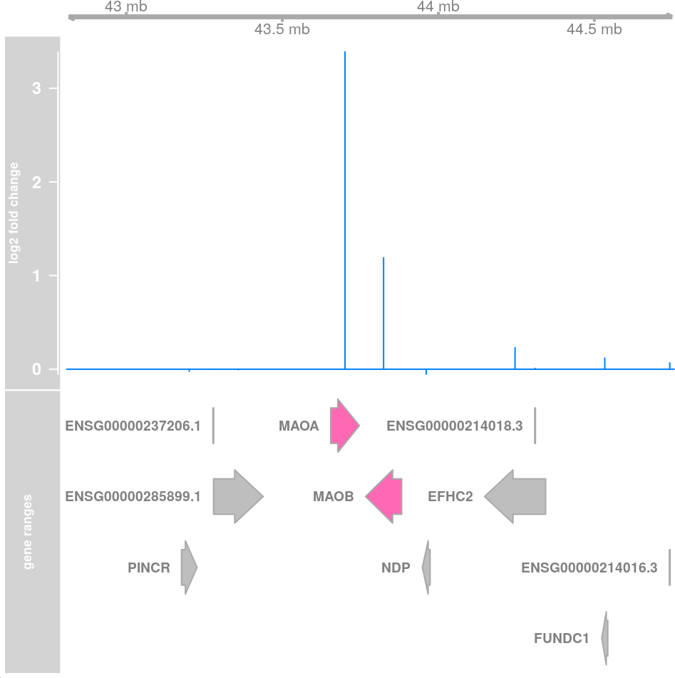

```r
options(ucscChromosomeNames = FALSE)
g <- GenomeAxisTrack()
a <- AnnotationTrack(resGRsub, name = "gene ranges", feature = status)
d <- DataTrack(resGRsub, data = "log2FoldChange", baseline = 0,
               type = "h", name = "log2 fold change", strand = "+")
plotTracks(list(g, d, a), groupAnnotation = "group",
           notsig = "grey", sig = "hotpink")
```

# 8 Removing hidden batch effects

Suppose we did not know that there were different cell lines involved in the experiment, only that there was treatment with dexamethasone. The cell line effect on the counts then would represent some hidden and unwanted variation that might be affecting many or all of the genes in the dataset. We can use statistical methods designed for RNA-seq from the *sva* package (Leek 2014) or the *RUVSeq* package (Risso et al. 2014) in Bioconductor to detect such groupings of the samples, and then we can add these to the *DESeqDataSet* design, in order to account for them.

The *SVA* package uses the term *surrogate variables* for the estimated variables that we want to account for in our analysis, while the RUV package uses the terms *factors of unwanted variation* with the acronym “Remove Unwanted Variation” explaining the package title. We first use *SVA* to find hidden batch effects and then *RUV* following.

## 8.1 Using SVA with DESeq2

```r
library("sva")
```

Below we obtain a matrix of normalized counts for which the average count across samples is larger than 1. As we described above, we are trying to recover any hidden batch effects, supposing that we do not know the cell line information. So we use a full model matrix with the *dex* variable, and a reduced, or null, model matrix with only an intercept term. Finally we specify that we want to estimate 2 surrogate variables. For more information read the manual page for the *svaseq* function by typing `?svaseq`.

```r
dat  <- counts(dds, normalized = TRUE)
idx  <- rowMeans(dat) > 1
dat  <- dat[idx, ]
mod  <- model.matrix(~ dex, colData(dds))
mod0 <- model.matrix(~   1, colData(dds))
svseq <- svaseq(dat, mod, mod0, n.sv = 2)
```

```
## Number of significant surrogate variables is:  2
## Iteration (out of 5 ):1  2  3  4  5
```

```r
svseq$sv
```

```
##            [,1]        [,2]
## [1,]  0.2465669 -0.51599084
## [2,]  0.2588137 -0.59462876
## [3,]  0.1384516  0.24920662
## [4,]  0.2179075  0.37716083
## [5,] -0.6042910 -0.06305844
## [6,] -0.6138795 -0.03623320
## [7,]  0.1821306  0.30328185
## [8,]  0.1743002  0.28026195
```

Because we actually do know the cell lines, we can see how well the SVA method did at recovering these variables (figure below).

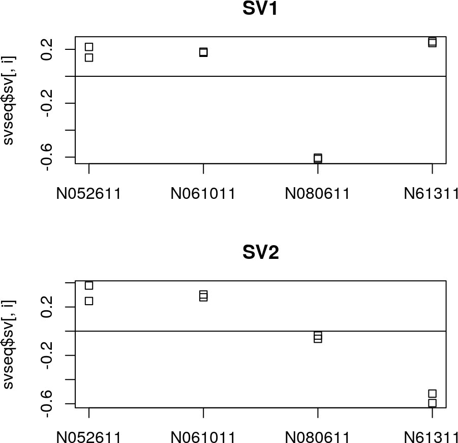

```r
par(mfrow = c(2, 1), mar = c(3,5,3,1))
for (i in 1:2) {
  stripchart(svseq$sv[, i] ~ dds$cell, vertical = TRUE, main = paste0("SV", i))
  abline(h = 0)
 }
```

**Surrogate variables 1 and 2 plotted over cell line.** Here, we know the hidden source of variation (cell line), and therefore can see how the SVA procedure is able to identify a source of variation which is correlated with cell line.

Finally, in order to use SVA to remove any effect on the counts from our surrogate variables, we simply add these two surrogate variables as columns to the *DESeqDataSet* and then add them to the design:

```r
ddssva <- dds
ddssva$SV1 <- svseq$sv[,1]
ddssva$SV2 <- svseq$sv[,2]
design(ddssva) <- ~ SV1 + SV2 + dex
```

We could then produce results controlling for surrogate variables by running *DESeq* with the new design.

## 8.2 Using RUV with DESeq2

We can also use the *RUV* method in the *RUVSeq* package to detect the hidden batch effects.

```r
library("RUVSeq")
```

We can use the `RUVg` function to estimate *factors of unwanted variation*, analogous to *SVA*’s *surrogate variables*. A difference compared to the *SVA* procedure above, is that we first would run *DESeq* and *results* to obtain the p-values for the analysis without knowing about the batches, e.g. just `~ dex`. Supposing that we have this results table `res`, we then pull out a set of *empirical control genes* by looking at the genes that do not have a small p-value.

```r
set <- newSeqExpressionSet(counts(dds))
idx  <- rowSums(counts(set) > 5) >= 2
set  <- set[idx, ]
set <- betweenLaneNormalization(set, which="upper")
not.sig <- rownames(res)[which(res$pvalue > .1)]
empirical <- rownames(set)[ rownames(set) %in% not.sig ]
set <- RUVg(set, empirical, k=2)
pData(set)
```

```
##                     W_1         W_2
## SRR1039508 -0.224881168  0.42992983
## SRR1039509 -0.249022928  0.53858506
## SRR1039512  0.001460949  0.01437385
## SRR1039513 -0.175547525  0.08408354
## SRR1039516  0.599387535 -0.02512358
## SRR1039517  0.590516825 -0.02549392
## SRR1039520 -0.241071948 -0.50369551
## SRR1039521 -0.300841739 -0.51265927
```

We can plot the factors estimated by *RUV*:

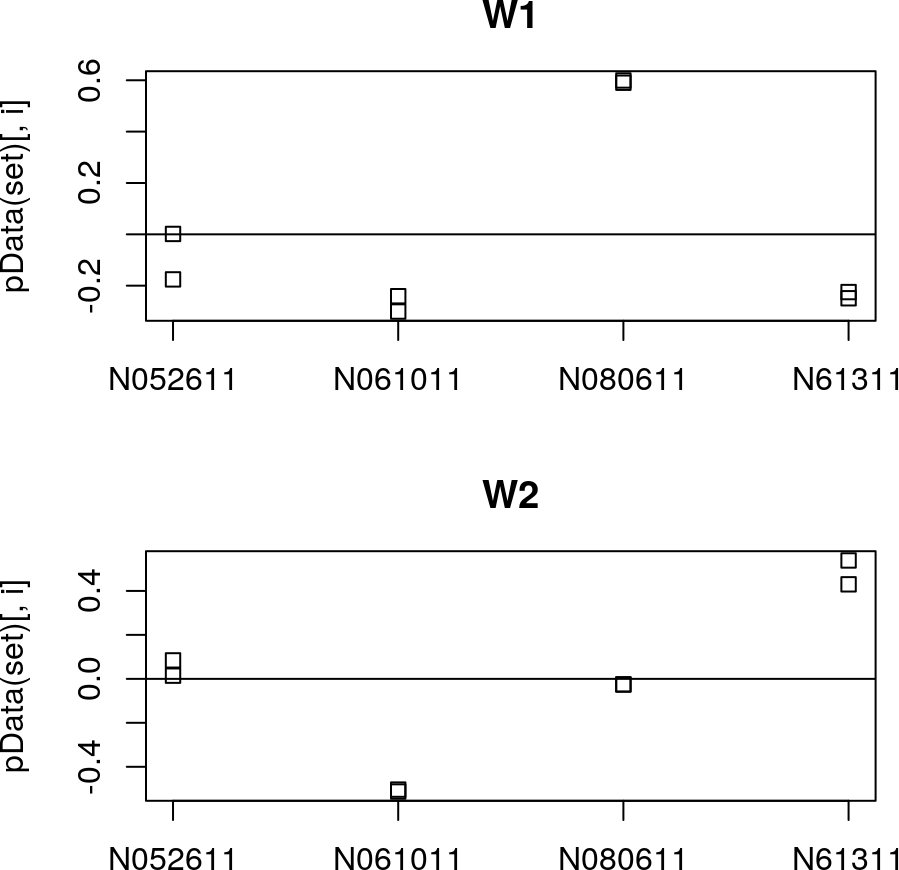

```r
par(mfrow = c(2, 1), mar = c(3,5,3,1))
for (i in 1:2) {
  stripchart(pData(set)[, i] ~ dds$cell, vertical = TRUE, main = paste0("W", i))
  abline(h = 0)
 }
```

**Factors of unwanted variation plotted over cell line.**

As before, if we wanted to control for these factors, we simply add them to the *DESeqDataSet* and to the design:

```r
ddsruv <- dds
ddsruv$W1 <- set$W_1
ddsruv$W2 <- set$W_2
design(ddsruv) <- ~ W1 + W2 + dex
```

We would then run *DESeq* with the new design to re-estimate the parameters and results.

# 9 Time course experiments

*DESeq2* can be used to analyze time course experiments, for example to find those genes that react in a condition-specific manner over time, compared to a set of baseline samples. Here we demonstrate a basic time course analysis with the *fission* data package, which contains gene counts for an RNA-seq time course of fission yeast (Leong et al. 2014). The yeast were exposed to oxidative stress, and half of the samples contained a deletion of the gene *atf21*. We use a design formula that models the strain difference at time 0, the difference over time, and any strain-specific differences over time (the interaction term `strain:minute`).

```r
library("fission")
data("fission")
ddsTC <- DESeqDataSet(fission, ~ strain + minute + strain:minute)
```

The following chunk of code performs a likelihood ratio test, where we remove the strain-specific differences over time. Genes with small *p* values from this test are those which at one or more time points after time 0 showed a strain-specific effect. Note therefore that this will not give small *p* values to genes that moved up or down over time in the same way in both strains.

```r
ddsTC <- DESeq(ddsTC, test="LRT", reduced = ~ strain + minute)
resTC <- results(ddsTC)
resTC$symbol <- mcols(ddsTC)$symbol
head(resTC[order(resTC$padj),], 4)
```

```
## log2 fold change (MLE): strainmut.minute180
## LRT p-value: '~ strain + minute + strain:minute' vs '~ strain + minute'
## DataFrame with 4 rows and 7 columns
##                      baseMean      log2FoldChange             lfcSE
##                     <numeric>           <numeric>         <numeric>
## SPBC2F12.09c 174.671161802578   -2.65671953167538 0.752261272510014
## SPAC1002.18  444.504950375698 -0.0509321395113488 0.204299484855652
## SPAC1002.19  336.373206596558  -0.392748982380864 0.573494009173081
## SPAC1002.17c 261.773132733438   -1.13876476912802 0.606128756827848
##                          stat               pvalue                 padj
##                     <numeric>            <numeric>            <numeric>
## SPBC2F12.09c 97.2833864066361 1.97415107456252e-19 1.33452612640426e-15
## SPAC1002.18  56.9535986228424 5.16955159216724e-11 1.74730843815253e-07
## SPAC1002.19  43.5339085770469 2.87980357352002e-08 6.48915738566511e-05
## SPAC1002.17c 39.3158355351574 2.05137078379587e-07 0.000346681662461502
##                   symbol
##              <character>
## SPBC2F12.09c       atf21
## SPAC1002.18         urg3
## SPAC1002.19         urg1
## SPAC1002.17c        urg2
```

This is just one of the tests that can be applied to time series data. Another option would be to model the counts as a smooth function of time, and to include an interaction term of the condition with the smooth function. It is possible to build such a model using spline basis functions within R, and another, more modern approach is using Gaussian processes (Tonner et al. 2017).

We can plot the counts for the groups over time using *ggplot2*, for the gene with the smallest adjusted *p* value, testing for condition-dependent time profile and accounting for differences at time 0 (figure below). Keep in mind that the interaction terms are the *difference* between the two groups at a given time after accounting for the difference at time 0.

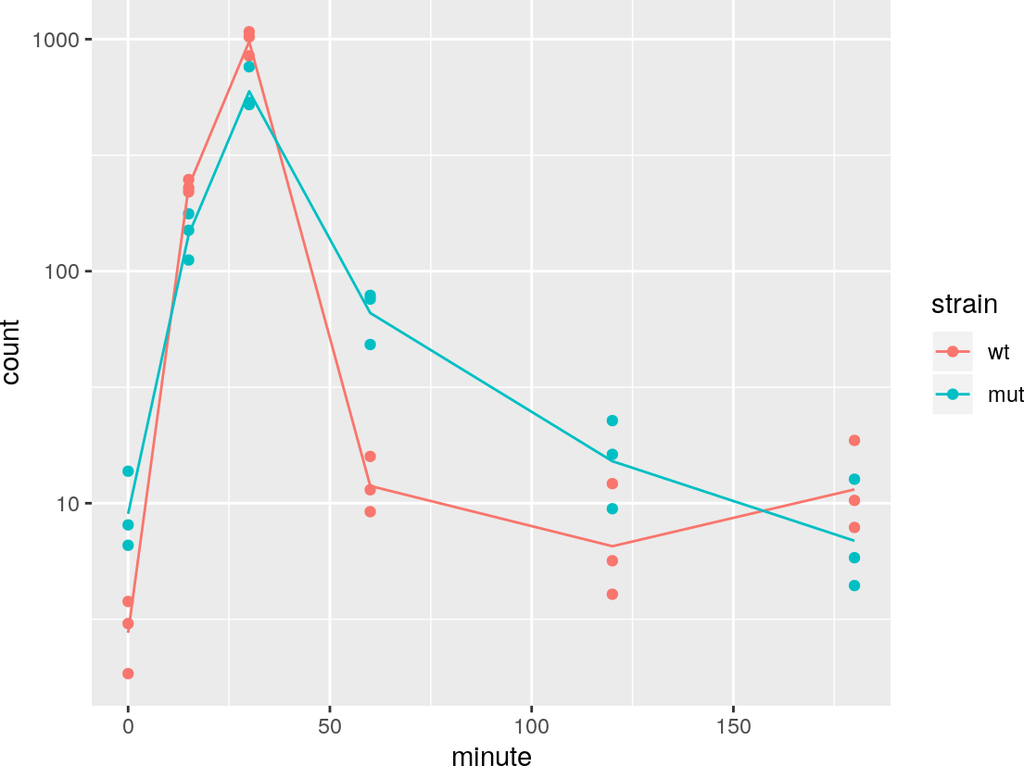

```r
fiss <- plotCounts(ddsTC, which.min(resTC$padj),
                   intgroup = c("minute","strain"), returnData = TRUE)
fiss$minute <- as.numeric(as.character(fiss$minute))
ggplot(fiss,
  aes(x = minute, y = count, color = strain, group = strain)) +
  geom_point() + stat_summary(fun.y=mean, geom="line") +
  scale_y_log10()
```

**Normalized counts for a gene with condition-specific changes over time.**

Wald tests for the log2 fold changes at individual time points can be investigated using the `test` argument to *results*:

```r
resultsNames(ddsTC)
```

```
##  [1] "Intercept"           "strain_mut_vs_wt"    "minute_15_vs_0"
##  [4] "minute_30_vs_0"      "minute_60_vs_0"      "minute_120_vs_0"
##  [7] "minute_180_vs_0"     "strainmut.minute15"  "strainmut.minute30"
## [10] "strainmut.minute60"  "strainmut.minute120" "strainmut.minute180"
```

```r
res30 <- results(ddsTC, name="strainmut.minute30", test="Wald")
res30[which.min(resTC$padj),]
```

```
## log2 fold change (MLE): strainmut.minute30
## Wald test p-value: strainmut.minute30
## DataFrame with 1 row and 6 columns
##                      baseMean    log2FoldChange             lfcSE
##                     <numeric>         <numeric>         <numeric>
## SPBC2F12.09c 174.671161802578 -2.60046902875453 0.634342916342926
##                           stat               pvalue              padj
##                      <numeric>            <numeric>         <numeric>
## SPBC2F12.09c -4.09946885471125 4.14099389594967e-05 0.279931187366198
```

```r
betas <- coef(ddsTC)
colnames(betas)
```

```
##  [1] "Intercept"           "strain_mut_vs_wt"    "minute_15_vs_0"
##  [4] "minute_30_vs_0"      "minute_60_vs_0"      "minute_120_vs_0"
##  [7] "minute_180_vs_0"     "strainmut.minute15"  "strainmut.minute30"
## [10] "strainmut.minute60"  "strainmut.minute120" "strainmut.minute180"
```

We can now plot the log2 fold changes in a heatmap (figure below).

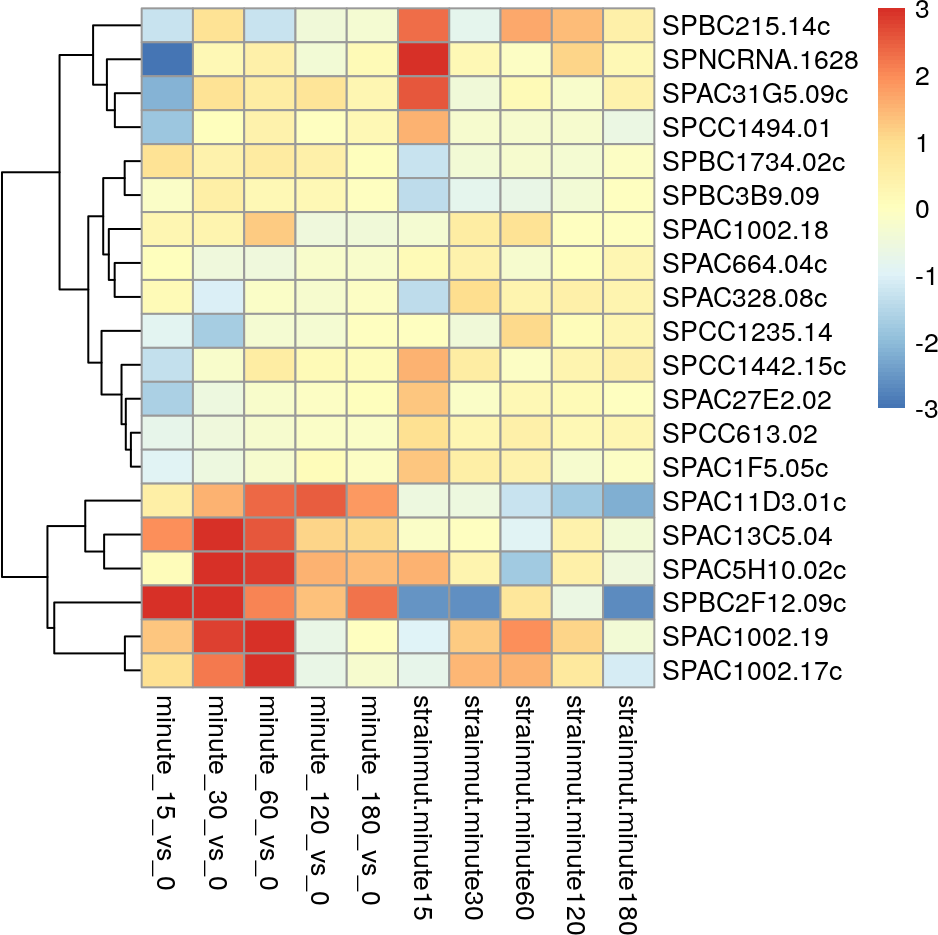

```r
topGenes <- head(order(resTC$padj),20)
mat <- betas[topGenes, -c(1,2)]
thr <- 3
mat[mat < -thr] <- -thr
mat[mat > thr] <- thr
pheatmap(mat, breaks=seq(from=-thr, to=thr, length=101),
         cluster_col=FALSE)
```

**Heatmap of log2 fold changes for genes with smallest adjusted *p* value.** The bottom set of genes show strong induction of expression for the baseline samples in minutes 15-60 (red boxes in the bottom left corner), but then have slight differences for the mutant strain (shown in the boxes in the bottom right corner).

# 10 Session information

As the last part of this document, we call the function *sessionInfo*, which reports the version numbers of R and all the packages used in this session. It is good practice to always keep such a record of this as it will help to track down what has happened in case an R script ceases to work or gives different results because the functions have been changed in a newer version of one of your packages. By including it at the bottom of a script, your reports will become more reproducible.

The session information should also *always* be included in any emails to the [Bioconductor support site](https://support.bioconductor.org) along with all code used in the analysis.

[session information not shown]

# References

Anders, Simon, and Wolfgang Huber. 2010. “Differential expression analysis for sequence count data.” *Genome Biology* 11 (10):R106+. https://doi.org/10.1186/gb-2010-11-10-r106.

Anders, Simon, Paul T. Pyl, and Wolfgang Huber. 2015. “HTSeq – a Python framework to work with high-throughput sequencing data.” *Bioinformatics* 31 (2):166–69. https://doi.org/10.1093/bioinformatics/btu638.

Benjamini, Yoav, and Yosef Hochberg. 1995. “Controlling the False Discovery Rate: A Practical and Powerful Approach to Multiple Testing.” *Journal of the Royal Statistical Society. Series B (Methodological)* 57 (1):289–300. http://www.jstor.org/stable/2346101.

Bourgon, R., R. Gentleman, and W. Huber. 2010. “Independent filtering increases detection power for high-throughput experiments.” *Proceedings of the National Academy of Sciences* 107 (21):9546–51. https://doi.org/10.1073/pnas.0914005107.

Bray, Nicolas, Harold Pimentel, Pall Melsted, and Lior Pachter. 2016. “Near-Optimal Probabilistic Rna-Seq Quantification.” *Nature Biotechnology* 34:525–27. http://dx.doi.org/10.1038/nbt.3519.

Dudoit, Rine, Yee H. Yang, Matthew J. Callow, and Terence P. Speed. 2002. “Statistical methods for identifying differentially expressed genes in replicated cDNA microarray experiments.” *Statistica Sinica*, 111–39.

Frankish, Adam, Alexandra Bignell, Andrew Berry, Andrew Yates, Anne Parker, Bianca M Schmitt, Bronwen Aken, et al. 2018. “GENCODE reference annotation for the human and mouse genomes.” *Nucleic Acids Research* 47 (D1):D766–D773.

Hardcastle, Thomas, and Krystyna Kelly. 2010. “baySeq: Empirical Bayesian methods for identifying differential expression in sequence count data.” *BMC Bioinformatics* 11 (1):422+. https://doi.org/10.1186/1471-2105-11-422.

Himes, Blanca E., Xiaofeng Jiang, Peter Wagner, Ruoxi Hu, Qiyu Wang, Barbara Klanderman, Reid M. Whitaker, et al. 2014. “RNA-Seq transcriptome profiling identifies CRISPLD2 as a glucocorticoid responsive gene that modulates cytokine function in airway smooth muscle cells.” *PloS One* 9 (6). https://doi.org/10.1371/journal.pone.0099625.

Huber, Wolfgang, Vincent J. Carey, Robert Gentleman, Simon Anders, Marc Carlson, Benilton S. Carvalho, Hector Corrada C. Bravo, et al. 2015. “Orchestrating high-throughput genomic analysis with Bioconductor.” *Nature Methods* 12 (2). Nature Publishing Group:115–21. https://doi.org/10.1038/nmeth.3252.

Huntley, Melanie A., Jessica L. Larson, Christina Chaivorapol, Gabriel Becker, Michael Lawrence, Jason A. Hackney, and Joshua S. Kaminker. 2013. “ReportingTools: an automated result processing and presentation toolkit for high-throughput genomic analyses.” *Bioinformatics* 29 (24). Oxford University Press:3220–1. https://doi.org/10.1093/bioinformatics/btt551.

Ignatiadis, Nikolaos, Bernd Klaus, Judith Zaugg, and Wolfgang Huber. 2016. “Data-Driven Hypothesis Weighting Increases Detection Power in Genome-Scale Multiple Testing.” *Nature Methods*. http://dx.doi.org/10.1038/nmeth.3885.

Köster, Johannes, and Sven Rahmann. 2012. “Snakemake - A scalable bioinformatics workflow engine.” *Bioinformatics*. https://doi.org/10.1093/bioinformatics/bts480.

Law, Charity W., Yunshun Chen, Wei Shi, and Gordon K. Smyth. 2014. “Voom: precision weights unlock linear model analysis tools for RNA-seq read counts.” *Genome Biology* 15 (2). BioMed Central Ltd:R29+. https://doi.org/10.1186/gb-2014-15-2-r29.

Lawrence, Michael, Wolfgang Huber, Hervé Pagès, Patrick Aboyoun, Marc Carlson, Robert Gentleman, Martin T. Morgan, and Vincent J. Carey. 2013. “Software for Computing and Annotating Genomic Ranges.” Edited by Andreas Prlic. *PLoS Computational Biology* 9 (8). Public Library of Science:e1003118+. https://doi.org/10.1371/journal.pcbi.1003118.

Leek, Jeffrey T. 2014. “svaseq: removing batch effects and other unwanted noise from sequencing data.” *Nucleic Acids Research* 42 (21). Oxford University Press:000. https://doi.org/10.1093/nar/gku864.

Leng, N., J. A. Dawson, J. A. Thomson, V. Ruotti, A. I. Rissman, B. M. G. Smits, J. D. Haag, M. N. Gould, R. M. Stewart, and C. Kendziorski. 2013. “EBSeq: an empirical Bayes hierarchical model for inference in RNA-seq experiments.” *Bioinformatics* 29 (8). Oxford University Press:1035–43. https://doi.org/10.1093/bioinformatics/btt087.

Leong, Hui S., Keren Dawson, Chris Wirth, Yaoyong Li, Yvonne Connolly, Duncan L. Smith, Caroline R. Wilkinson, and Crispin J. Miller. 2014. “A global non-coding RNA system modulates fission yeast protein levels in response to stress.” *Nature Communications* 5. https://doi.org/10.1038/ncomms4947.

Li, Bo, and Colin N. Dewey. 2011. “RSEM: accurate transcript quantification from RNA-Seq data with or without a reference genome.” *BMC Bioinformatics* 12:323+. https://doi.org/10.1186/1471-2105-12-3231.

Liao, Y., G. K. Smyth, and W. Shi. 2014. “featureCounts: an efficient general purpose program for assigning sequence reads to genomic features.” *Bioinformatics* 30 (7). Oxford University Press:923–30. https://doi.org/10.1093/bioinformatics/btt656.

Love, Michael I., John B. Hogenesch, and Rafael A. Irizarry. 2016. “Modeling of Rna-Seq Fragment Sequence Bias Reduces Systematic Errors in Transcript Abundance Estimation.” *Nature Biotechnology* 34 (12):1287–91. http://dx.doi.org/10.1038/nbt.3682.

Love, Michael I., Wolfgang Huber, and Simon Anders. 2014. “Moderated estimation of fold change and dispersion for RNA-seq data with DESeq2.” *Genome Biology* 15 (12). BioMed Central Ltd:550+. https://doi.org/10.1186/s13059-014-0550-8.

Love, Michael I., Charlotte Soneson, Peter F. Hickey, Lisa K. Johnson, N. Tessa Pierce, Lori Shepherd, Martin Morgan, and Rob Patro. 2019. “Tximeta: reference sequence checksums for provenance identification in RNA-seq.” *bioRxiv*. https://doi.org/10.1101/777888.

Patro, Rob, Geet Duggal, Michael I. Love, Rafael A. Irizarry, and Carl Kingsford. 2017. “Salmon Provides Fast and Bias-Aware Quantification of Transcript Expression.” *Nature Methods*. http://dx.doi.org/10.1038/nmeth.4197.

Risso, Davide, John Ngai, Terence P. Speed, and Sandrine Dudoit. 2014. “Normalization of RNA-seq data using factor analysis of control genes or samples.” *Nature Biotechnology* 32 (9). Nature Publishing Group:896–902. https://doi.org/10.1038/nbt.2931.

Robert, Christelle, and Mick Watson. 2015. “Errors in RNA-Seq quantification affect genes of relevance to human disease.” *Genome Biology*. https://doi.org/10.1186/s13059-015-0734-x.

Robinson, M. D., D. J. McCarthy, and G. K. Smyth. 2009. “edgeR: a Bioconductor package for differential expression analysis of digital gene expression data.” *Bioinformatics* 26 (1). Oxford University Press:139–40. https://doi.org/10.1093/bioinformatics/btp616.

Schurch, Nicholas J., Pieta Schofield, Marek Gierlinski, Christian Cole, Alexander Sherstnev, Vijender Singh, Nicola Wrobel, et al. 2016. “How Many Biological Replicates Are Needed in an Rna-Seq Experiment and Which Differential Expression Tool Should You Use?” 22 (6):839–51. https://doi.org/10.1261/rna.053959.115.

Soneson, Charlotte, Michael I. Love, and Mark Robinson. 2015. “Differential analyses for RNA-seq: transcript-level estimates improve gene-level inferences.” *F1000Research* 4 (1521). https://doi.org/10.12688/f1000research.7563.1.

Tonner, Peter D, Cynthia L Darnell, Barbara E Engelhardt, and Amy K Schmid. 2017. “Detecting differential growth of microbial populations with Gaussian process regression.” *Genome Research* 27:320–33. https://doi.org/10.1101/gr.210286.116.

Townes, F. William, Stephanie C. Hicks, Martin J. Aryee, and Rafael A. Irizarry. 2019. “Feature Selection and Dimension Reduction for Single Cell Rna-Seq Based on a Multinomial Model.” *bioRxiv*. Cold Spring Harbor Laboratory. https://doi.org/10.1101/574574.

Trapnell, Cole, David G Hendrickson, Martin Sauvageau, Loyal Goff, John L Rinn, and Lior Pachter. 2013. “Differential analysis of gene regulation at transcript resolution with RNA-seq.” *Nature Biotechnology*. https://doi.org/10.1038/nbt.2450.

Wickham, Hadley. 2009. *ggplot2*. New York, NY: Springer New York. https://doi.org/10.1007/978-0-387-98141-3.

Witten, Daniela M. 2011. “Classification and clustering of sequencing data using a Poisson model.” *The Annals of Applied Statistics* 5 (4):2493–2518. https://doi.org/10.1214/11-AOAS493.

Wu, Hao, Chi Wang, and Zhijin Wu. 2013. “A new shrinkage estimator for dispersion improves differential expression detection in RNA-seq data.” *Biostatistics* 14 (2). Oxford University Press:232–43. https://doi.org/10.1093/biostatistics/kxs033.

Zhu, Anqi, Joseph G. Ibrahim, and Michael I. Love. 2018. “Heavy-Tailed Prior Distributions for Sequence Count Data: Removing the Noise and Preserving Large Differences.” *bioRxiv*. https://doi.org/10.1101/303255.